# Mieten in Deutschland

Worin liegen Probleme und Schwierigkeiten im deutschen Mietmarkt

# Motivation

Die Mietpreise in Deutschland spielen eine wichtige Rolle für eine Vielzahl der deutschen Bevölkerung, doch nicht alle Gemeinden sind gleichermaßen von hohen Mieten betroffen. Faktoren wie die Lage einer Stadt, das Angebot an Wohnraum, das Alter der Gebäude oder der Familienstand der Bewohner beeinflussen die Höhe der Mieten. Dies werden Sie in diesem Projekt anhand von Zensus-Daten auf Gemeindeebene für das Jahr 2022 genau untersuchen. Besonders interessant ist dabei, wie sich Mietpreise nicht nur zwischen verschiedenen Städten, sondern auch innerhalb einer Stadt unterscheiden. Sie werden feststellen, dass die Ursachen für diese Mietunterschiede komplex und vielschichtig sind. Ihre Aufgabe ist es, durch fundierte Analysen herauszuarbeiten, welche Faktoren den größten Einfluss auf die Mietentwicklung haben. Auf Basis dieser Erkenntnisse könnten Sie Handlungsempfehlungen geben, die Politik und Stadtplaner nutzen können, um die Mietpreisentwicklung besser zu steuern und Wohnraum gerechter zu gestalten.

# Datengrundlage

In diesem Projekt werden Sie mit mehreren unterschiedlichen Datensätzen arbeiten. Zum Einen werden Sie Zensusdaten aus dem Jahr 2022 zur Demografie genauer betrachten. Zum Anderen werden Sie Daten zur Wohnungszählung in deutschen Gemeinden und Städten untersuchen. Schließlich benötigen Sie die dazugehörigen Kartendaten, um die Informationen später anschaulich visualisieren zu können. Dort werden Sie die Details der Karten einlesen und darüber hinaus Zahlen zu Mieten selbstständig herunterladen und importieren.

## Einlesen

Mittlerweile wohnen knapp 54% der Menschen in Deutschland zur Miete (Stand 2022). Somit ist Deutschland das Mieterland Nummer 1 in Europa. Im Vergleich dazu haben Länder wie Frankreich (36,6%), Italien (25,7%) oder Spanien (24%) einen deutlich geringeren Anteil an Mietern. Für die Politik ist es besonders interessant zu erfahren, wie sich nun die Mieten in den unterschiedlichen Gemeinden in Deutschland verteilen und ob es Regionen gibt, wo es besonders schwer wird eine neue Wohnung zu finden. Um dies zu beleuchten, sollen Sie nun die nachfolgenden Datensätze genauer analysieren.

1. Lesen Sie den Datensatz `Demografie_Zensus.csv` ein und speichern diesen als `demografie`. Der Datensatz `demografie` enthält für jede Gemeinde mehrere Beobachtungen. Dies liegt daran, dass für jede Altersgruppe der Personen eine eigene Beobachtung vorliegt. Allerdings ist der Datensatz im long-Format, d.h. nicht tidy und damit nicht so, wie Sie ihn für die weitere Datenanalyse benötigen. Nun soll der Datensatz so abgeändert werden, dass jede Gemeinde nur noch eine Beobachtung darstellt. Passen Sie den Datensatz so an, dass Sie für jede `Altersgruppe` eine eigene Spalte erstellen und dort jeweils die Anzahl der Menschen, die Sie der Spalte `Anzahl pro Altersgruppe` entnehmen können, eingetragen wird.

Darüberhinaus sollen Sie nun einen weiteren Datensatz `Wohnungen_Zensus.csv` einlesen, welcher Informationen zu den einzelnen Wohnungen in den Gemeinden enthält. Speichern Sie den Datensatz in der Variable `wohnungen` ab. Vereinen Sie ihren Datensatz `demografie` mit dem Datensatz `wohnungen` und speichern Sie diesen als `zensus_daten` ab. Verwenden Sie für ihren “Join” die Variable `Regionalschlüssel`.

Beantworten Sie anschließend die Frage, welche Art von “Join” sich in diesem Fall anbietet und warum?

Zensus-Daten

| Name_Gemeinde.x | Landkreis.x | Regionalschlüssel | 0_Insgesamt_ | GESCHLECHT__1 | Weitere Spalten |
| --- | --- | --- | --- | --- | --- |
| Flensburg, Stadt | Flensburg, Stadt | 10010000000 | 95015 | 46834 | …. |
| Kiel, Landeshauptstadt | Kiel, Landeshauptstadt | 10020000000 | 249132 | 121818 | …. |
| Lübeck, Hansestadt | Lübeck, Hansestadt | 10030000000 | 215958 | 103625 | …. |
| Neumünster, Stadt | Neumünster, Stadt | 10040000000 | 79625 | 39465 | …. |
| Brunsbüttel, Stadt | Dithmarschen | 10510011011 | 12573 | 6312 | …. |
| Heide, Stadt | Dithmarschen | 10510044044 | 21487 | 10416 | …. |

Demografie (tidy Format)

| Name_Gemeinde | Landkreis | Regionalschlüssel | 0_Insgesamt_ | GESCHLECHT__1 | Weitere Spalten |
| --- | --- | --- | --- | --- | --- |
| Flensburg, Stadt | Flensburg, Stadt | 10010000000 | 95015 | 46834 | …. |
| Kiel, Landeshauptstadt | Kiel, Landeshauptstadt | 10020000000 | 249132 | 121818 | …. |
| Lübeck, Hansestadt | Lübeck, Hansestadt | 10030000000 | 215958 | 103625 | …. |
| Neumünster, Stadt | Neumünster, Stadt | 10040000000 | 79625 | 39465 | …. |
| Brunsbüttel, Stadt | Dithmarschen | 10510011011 | 12573 | 6312 | …. |
| Heide, Stadt | Dithmarschen | 10510044044 | 21487 | 10416 | …. |

Wohnungen

| …1 | Name_Gemeinde | Landkreis | Regionalschlüssel | BAUJAHR_10JA__01 | Weitere Spalten |
| --- | --- | --- | --- | --- | --- |
| 1 | Flensburg, Stadt | Flensburg, Stadt | 10010000000 | 10829 | …. |
| 2 | Kiel, Landeshauptstadt | Kiel, Landeshauptstadt | 10020000000 | 24738 | …. |
| 3 | Lübeck, Hansestadt | Lübeck, Hansestadt | 10030000000 | 19384 | …. |
| 4 | Neumünster, Stadt | Neumünster, Stadt | 10040000000 | 4575 | …. |
| 5 | Brunsbüttel, Stadt | Dithmarschen | 10510011011 | 822 | …. |
| 6 | Heide, Stadt | Dithmarschen | 10510044044 | 1432 | …. |

Es bietet sich ein left_join an, da wir alle Daten aus dem demografie-Datensatz behalten wollen und nur die passenden Daten aus dem wohnungen-Datensatz hinzufügen möchten.

2. Schränken Sie nun Ihren erstellten Datensatz auf folgende Variablen ein:
- `Name_Gemeinde`
- `Landkreis`
- `0_Insgesamt_`
- `Regionalschlüssel`
- `Alter_infr__` (01 bis 11)
- `FAMSTND_KURZ__` (1 bis 5)
- `Einwanderungserf_ausf__1`
- `Einwanderungserf_ausf__21`
- `Einwanderungserf_ausf__22`
- `Einwanderungserf_ausf__3`
- `Staatsange_kurz__1`
- `Staatsange_kurz__2`
- `BAUJAHR_10JA__` (01 bis 10)
- `WOHNFLAECHE_20S__` (01 bis 10)
- `QMMIETE`
- `LEQ`
- `ETQ`
- `FLAECHE`
- `Wohnungen_gesamt`

Beschreiben Sie weiterhin den Datensatz. Orientieren Sie sich hierbei an folgenden Fragen und nutzen Sie das bereitgestellte README zum Datensatz:

- Was ist eine Beobachtung?
- Wie viele Variablen hat der Datensatz?
- Welche Variablen enthält der Datensatz? Bitte beschreiben Sie diese Variablen kurz!
- Welche Städte mit mehr als 500.000 Einwohnern sind im Datensatz?
- In wie viel Prozent der Fälle haben Sie Informationen zu allen Variablen einer Beobachtung?

Eingeschränkte Zensus-Daten

| Regionalschlüssel | Name_Gemeinde.x | Landkreis.x | BAUJAHR_10JA__01 | BAUJAHR_10JA__02 | Weitere Spalten |
| --- | --- | --- | --- | --- | --- |
| 10010000000 | Flensburg, Stadt | Flensburg, Stadt | 10829 | 5612 | …. |
| 10020000000 | Kiel, Landeshauptstadt | Kiel, Landeshauptstadt | 24738 | 22646 | …. |
| 10030000000 | Lübeck, Hansestadt | Lübeck, Hansestadt | 19384 | 16992 | …. |
| 10040000000 | Neumünster, Stadt | Neumünster, Stadt | 4575 | 5537 | …. |
| 10510011011 | Brunsbüttel, Stadt | Dithmarschen | 822 | 552 | …. |
| 10510044044 | Heide, Stadt | Dithmarschen | 1432 | 1320 | …. |

Eine Beobachtung in diesem Datensatz ist eine spezifische Gemeinde mit einer Vielzahl an Daten zur Alterstruktur, den Wohnungen oder weiteren sozialen Angaben, die sich auf diese Gemeinde beziehen.

| Anzahl der Spalten des Datensatzes: |
| --- |
| 51 |

Der Datensatz hat insgesamt 50 Variablen und eine Spalte zur Nummerierung.

Diese lassen sich wie folgend beschreiben:

- Regionalschlüssel: Amtlicher Gemeindeschlüssel, der die Gemeinde identifiziert.
- Name_Gemeinde.x: Name der Gemeinde.
- Landkreis.x: Name des zugehörigen Landkreises.
- BAUJAHR_10JA_XX: Anzahl der Wohnungen pro Baujahrkategorie (z.B. 1919-1949, 1950-1959, etc.).
- WOHNFLAECHE_20S_XX: Anzahl der Wohnungen pro Wohnflächenkategorie (z.B. unter 40m^2, 40m<sup>2-59m</sup>2, etc.).
- QMMIETE: Durchschnittliche Nettokaltmiete pro Quadratmeter.
- LEQ: Leerstandsquote in Prozent.
- ETQ: Eigentümerquote in Prozent.
- FLAECHE: Durchschnittliche Fläche je Wohnung in m^2.
- 0_Insgesamt: Gesamtbevölkerung der Gemeinde.
- Staatsange_kurz_XX: Anzahl der Personen nach Staatsangehörigkeit (deutsch, nicht-deutsch).
- Alter_infr_XX: Anzahl der Personen in bestimmten Altersgruppen.
- FAMSTND_KURZ_XX: Anzahl der Personen nach Familienstand.
- Einwanderungserf_ausf_XX: Einwanderungserfahrungen von Personen.

| Anzahl Gemeinden mit Bevölkerungsanzahl >500 000: |
| --- |
| 15 |

Zudem werden insgesamt 15 Gemeinden aufgeführt, deren Gesamtbevölkerungsanzahl 500.000 überschreitet.

| Informationen zu allen Variablen einer Beobachtung in %: |
| --- |
| 98.58 |

Weiterhin sind in 98.58% der Fälle Informationen zu allen Variablen einer Beobachtung gegeben.

3. Erstellen Sie in einem nächsten Schritt weitere Variablen, die Sie in ihrer Analyse benötigen. Diese Variablen sollen folgende Eigenschaften umfassen:
- Je eine Variable für den Anteil kleiner, mittlerer und großer Wohnungen, wobei kleine Wohnungen (<= 59 m²), mittlere Wohnungen (60 - 159 m²) und große Wohnungen (>= 160 m²) als Anteil an den `Wohnungen_gesamt` abgebildet werden sollen.
- Je eine Variable für den Anteil neuer und alter Wohnungen. Neue Wohnungen umfassen alle Wohnungen, die ab 2010 gebaut wurden und alte Wohnungen sind alle Wohnungen vor 1950. Auch hier soll wieder der Anteil an allen Wohnungen (`Wohnungen_gesamt`) berechnet werden.
- Das Verhältnis von Personen mit deutscher Staatsangehörigkeit zu allen Bürgern der Gemeinde einschliesslich Personen mit ausländischer Staatsangehörigkeit und Personen mit dem Status “staatenlos”, “ungeklärt” und “ohne Angabe” über `Staatsange_kurz__1` und `Staatsange_kurz__2`. Hier soll der Anteil deutscher Bürger im Verhältnis zu allen Bürgern der Gemeinde bestimmt werden.

*Hinweis:* Runden Sie die Werte für die neu erstellte Variable sinnvoll!

Erweiterter Zensus-Datensatz

| Regionalschlüssel | Name_Gemeinde.x | Landkreis.x | BAUJAHR_10JA__01 | BAUJAHR_10JA__02 | Weitere Spalten |
| --- | --- | --- | --- | --- | --- |
| 10010000000 | Flensburg, Stadt | Flensburg, Stadt | 10829 | 5612 | …. |
| 10020000000 | Kiel, Landeshauptstadt | Kiel, Landeshauptstadt | 24738 | 22646 | …. |
| 10030000000 | Lübeck, Hansestadt | Lübeck, Hansestadt | 19384 | 16992 | …. |
| 10040000000 | Neumünster, Stadt | Neumünster, Stadt | 4575 | 5537 | …. |
| 10510011011 | Brunsbüttel, Stadt | Dithmarschen | 822 | 552 | …. |
| 10510044044 | Heide, Stadt | Dithmarschen | 1432 | 1320 | …. |

4. Um Karten wie bspw. in der Case Study zu erstellen, benötigen Sie Kartendaten in Form von Shapefiles (Endung .shp). In einer späteren Analyse sollen Sie die einzelnen Städte, bzw. deren Bezirke visualisieren. Hierzu müssen Sie zuerst die nötigen Shape-Files einlesen und Details zu den einzelnen Bezirken herunterladen. Sie sollen Analysen auf Basis von 1km Gitterdaten durchführen. Deshalb sollten Sie sich [diese Geogitter-Daten für die Nettokaltmieten vom statistischen Bundesamt herunterladen](https://www.zensus2022.de/static/Zensus_Veroeffentlichung/Zensus2022_Durchschn_Nettokaltmiete.zip). Speichern Sie die zip-Datei im Ordner `Daten` ab. Weiterhin sollen Sie [die Geogitter-Daten für die Leerstandsquoten herunterladen](https://www.zensus2022.de/static/Zensus_Veroeffentlichung/Marktaktive_Leerstandsquote_in_Gitterzellen.zip). Speichern Sie auch diese im Ordner `Daten` ab und lesen Sie anschließend die .csv-Dateien für Nettokaltmiete und Leerstandsquote (für das 1km-Gitter) ein. Weiterhin benötigen Sie die Karteninformationen für die Visualisierung der Daten. Diese befinden sich in der Datei `Shapefile_Zensus.shp`. Lesen Sie diese mit Hilfe von `st_read()` ein und speichern Sie als `shape_file` ab. Benennen Sie die Variablen in `shape_file` folgendermaßen um:
- gemndnm = Name_Gemeinde
- x_mp_1k = x_mp_1km
- y_mp_1k = y_mp_1km
- gttr1km = gitter1km

Joinen Sie nun noch die beiden Dataframes zu Miete und Leerstandsquote zu `shape_file` hinzu. Verwenden Sie `y_mp_1km` und `x_mp_1km` als Joinvariable.

*Hinweis:* Im ersten Teil der Case-Study wird eine ZIP-Datei in R entpackt. Gehen Sie hier gleich vor!

Verknüpfter Shape File Datensatz (erste 10 Zeilen)

| Name_Gemeinde | x_mp_1km | y_mp_1km | gitter1km | GITTER_ID_1km.x | durchschnMieteQM | werterlaeuternde_Zeichen.x | GITTER_ID_1km.y | MALeerstQuote | werterlaeuternde_Zeichen.y |
| --- | --- | --- | --- | --- | --- | --- | --- | --- | --- |
| Friedrichshafen, Stadt | 4283500 | 2725500 | 1kmN2725E4283 | CRS3035RES1000mN2725000E4283000 | 11,11 |  | NA | NA | NA |
| Friedrichshafen, Stadt | 4284500 | 2725500 | 1kmN2725E4284 | NA | NA | NA | CRS3035RES1000mN2725000E4284000 | – |  |
| Friedrichshafen, Stadt | 4279500 | 2726500 | 1kmN2726E4279 | NA | NA | NA | NA | NA | NA |
| Friedrichshafen, Stadt | 4280500 | 2726500 | 1kmN2726E4280 | CRS3035RES1000mN2726000E4280000 | 9,19 |  | CRS3035RES1000mN2726000E4280000 | 3,02 |  |
| Friedrichshafen, Stadt | 4281500 | 2726500 | 1kmN2726E4281 | CRS3035RES1000mN2726000E4281000 | 9,22 |  | CRS3035RES1000mN2726000E4281000 | 1,33 |  |
| Friedrichshafen, Stadt | 4282500 | 2726500 | 1kmN2726E4282 | CRS3035RES1000mN2726000E4282000 | 8,66 |  | CRS3035RES1000mN2726000E4282000 | 1,55 |  |
| Friedrichshafen, Stadt | 4283500 | 2726500 | 1kmN2726E4283 | CRS3035RES1000mN2726000E4283000 | 8,02 |  | CRS3035RES1000mN2726000E4283000 | 0,95 | KLAMMERN |
| Friedrichshafen, Stadt | 4284500 | 2726500 | 1kmN2726E4284 | NA | NA | NA | CRS3035RES1000mN2726000E4284000 | – |  |
| Konstanz, Universitätsstadt | 4257500 | 2727500 | 1kmN2727E4257 | NA | NA | NA | NA | NA | NA |
| Konstanz, Universitätsstadt | 4258500 | 2727500 | 1kmN2727E4258 | CRS3035RES1000mN2727000E4258000 | 10,59 |  | CRS3035RES1000mN2727000E4258000 | 0,98 |  |

# Konsistenzcheck

Nun haben Sie alle Daten zusammen, die Sie für die Analyse der Mieten in Deutschland für das Jahr 2022 benötigen. Somit können Sie nun beginnen, die ersten Analysen zu tätigen!

5. Im Datensatz `zensus_daten`, welchen Sie zuvor eingelesen, aufgearbeitet und zusammengefügt haben, befinden sich einige große deutsche Städte. Sie möchten nun gerne die Daten, welche Sie dort aufbereitet haben, verifizieren. Dafür sollten Sie sich eine externe Quelle suchen, auf deren Basis Sie die Gesamtbevölkerung der unten aufgeführten großen Städte in Deutschland mit denen aus dem Datensatz vergleichen. Die Bevölkerungszahlen in ihrem Datensatz stammen aus dem Jahr 2022.

Erstellen Sie eine Tabelle mit allen nachfolgenden Städten aus dem Datensatz und deren Einwohnern. Achten Sie auf eine schöne Darstellung ihrer Tabelle mittels der Pakete `kableExtra` oder `gt`.

Im Detail sollen folgende Städte in der Tabelle genauer betrachtet werden:

- “Berlin, Stadt”, “Hamburg, Freie und Hansestadt”, “München, Landeshauptstadt”, “Köln, Stadt”, “Frankfurt am Main, Stadt”, “Stuttgart, Landeshauptstadt”, “Düsseldorf, Stadt”, “Leipzig, Stadt”, “Augsburg”, “Ingolstadt”, “Ulm, Universitätsstadt”, “Reutlingen, Stadt”

Sind die Anzahl der Einwohner in ihren Daten korrekt? Nutzen Sie eine externe Datenquelle (bitte benennen und in ihrer Antwort verlinken) und führen Sie einen kurzen Konsistenzcheck durch.

| Stadt | Einwohner 2022 |
| --- | --- |
| Hamburg, Freie und Hansestadt | 1808846 |
| Düsseldorf, Stadt | 611258 |
| Köln, Stadt | 1017355 |
| Frankfurt am Main, Stadt | 743268 |
| Stuttgart, Landeshauptstadt | 610458 |
| Reutlingen, Stadt | 116925 |
| Ulm, Universitätsstadt | 127116 |
| Ingolstadt | 136468 |
| München, Landeshauptstadt | 1478638 |
| Augsburg | 294647 |
| Berlin, Stadt | 3596999 |
| Leipzig, Stadt | 598899 |

Informationen zur Darstellung der Tabelle mit ‘kableextra’ haben wir dem “Cran.R-Project” entnommen (https://cran.r-project.org/web/packages/kableExtra/vignettes/awesome_table_in_html.html).

Für unseren Konsistenzcheck haben wir die Daten des Statistsichen Bundesamt Deutschland verwendet (https://www.destatis.de/DE/Themen/Laender-Regionen/Regionales/Gemeindeverzeichnis/Administrativ/05-staedte.html). Die Datei “05-staedte” gibt uns zuverlässige und vergleichbare Daten zu den Gemeinden und deren Einwohnerzahlen in 2022.

| Stadt | Einwohner im Zensus-Datensatz | Einwohner in Vergleichsquelle |
| --- | --- | --- |
| Hamburg, Freie und Hansestadt | 1808846 | 1892122 |
| Düsseldorf, Stadt | 611258 | 629047 |
| Köln, Stadt | 1017355 | 1084831 |
| Frankfurt am Main, Stadt | 743268 | 773068 |
| Stuttgart, Landeshauptstadt | 610458 | 632865 |
| Reutlingen, Stadt | 116925 | 117547 |
| Ulm, Universitätsstadt | 127116 | 128928 |
| Ingolstadt | 136468 | 141029 |
| München, Landeshauptstadt | 1478638 | 1512491 |
| Augsburg | 294647 | 301033 |
| Berlin, Stadt | 3596999 | 3755251 |
| Leipzig, Stadt | 598899 | 616093 |

In der Graphik “vergleichtsabelle_clean” sehen wir, dass es leichte Diskrepanzen zwischen den beiden Quellen gibt. Da sich diese aber im Vergleich zu der Größe der Zahlen sehr klein verhalten, könnten diese aufgrund von unterschiedlichen Erfassungsmethoden, Rundungsunterschieden oder anderen Aktualitäten entstanden sein. Insgesamt schätzten wir unsere Daten so als konsistent ein.

# Deskriptive Analysen

6. Schauen Sie sich in einem nächsten Schritt an, wie die Variablen im Datensatz `zensus_daten` über alle Gemeinden und Städte hinweg verteilt sind. Konkret sollten Sie eine Tabelle erstellen, welche Informationen zu folgenden Variablen enthält:
- verschiedene Baujahre der Wohnungen
- durchschnittlicher Quadratmeterpreis
- Leerstandsquote
- Eigentümerquote
- durchschnittliche Wohnfläche
- Anteil kleiner, mittlerer und großer Wohnungen
- Einwohner

Berechnen Sie zu jeder Variablen den Mittelwert, den Median, das Minimum, das Maximum, die Standardabweichung, sowie das 25%- und das 75%- Quantil bezogen auf alle Gemeinden. Bei den Variablen Leerstandsquote, Eigentümerquote, durchschnittliche Wohnfläche, durchschnittlicher Quadratmeterpreis und Anteil kleiner, mittlerer und großer Wohnungen soll der Mittelwert als gewichteter Mittelwert nach der absoluten Anzahl an Wohnungen berechnet werden. Heben Sie die Variablen in ihrer Tabelle entsprechend hervor, bei denen sie den gewichteten Mittelwert bestimmt haben.

Beschreiben und interpretieren Sie Ihre Tabelle. Begründen Sie auch, warum es bei den genannten Variablen sinnvoll ist, den nach Anzahl der Wohnungen gewichteten Mittelwert zu verwenden. Würde es ihrer Ansicht nach Sinn machen, statt nach Wohnungen nach Einwohnern zu gewichten? Begründen Sie auch, bei welchen Variablen eine Betrachtung der Mittelwerte, Standardabweichungen und Quantile ihrer Ansicht nach als sinnvoll erscheint. Wo ist dies weniger gut geeignet? Bei welchen Variablen gibt es Auffälligkeiten? Gibt es Ausreißer nach oben oder unten?

Achten Sie auf eine schöne Darstellung ihrer Tabelle mittels der Pakete `kableExtra` oder `gt`!

*Hinweis 1:* Wenn bei den Variablen Wohnungen_klein, Wohnungen_mittel und Wohnungen_groß Werte mit `NaN` oder `Inf` auftauchen, so ersetzen Sie diese durch `NAs`.

*Hinweis 2:* Die Anzahl der Wohnungen nach Alters- bzw. Baujahrsgruppen können den Variablen entnommen werden, welche mit `BAUJAHR_10JA__` beginnen.

| Variable | Mittelwert | Median | Min | Max | SD | Q25 | Q75 | Gewichteter_Mittelwert |
| --- | --- | --- | --- | --- | --- | --- | --- | --- |
| Baujahre | 19291.01 | 87.60 | 0.30 | 201883.00 | 2748.20 | 32.55 | 274.65 | Ja |
| QMP | NA | 5.53 | 0.00 | 13.84 | 1.38 | 4.82 | 6.46 | Ja |
| Leerstandsquote | NA | 4.74 | 0.00 | 50.00 | 3.11 | 3.45 | 6.58 | Ja |
| Eigentümerquote | NA | 68.77 | 13.49 | 100.00 | 12.72 | 60.22 | 76.11 | Ja |
| Durchschnittliche Wohnfläche | NA | 116.20 | 64.92 | 239.54 | 15.41 | 104.98 | 125.11 | Ja |
| Anteil kleine Wohnungen | 23.17 | 8.86 | 0.00 | 58.96 | 8.04 | 5.75 | 14.24 | Ja |
| Anteil mittlere Wohnungen | 67.72 | 72.99 | 0.00 | 147.06 | 6.46 | 69.16 | 76.01 | Ja |
| Anteil große Wohnungen | 9.12 | 16.32 | 0.00 | 85.71 | 7.67 | 11.08 | 21.37 | Ja |
| Einwohner | 7668.39 | 1797.00 | 9.00 | 3596999.00 | 49519.18 | 655.25 | 5505.00 | Nein |

<sup>a</sup> Die Zellen mit ‘lightblue’ Hintergrund haben den gewichteten Mittelwert.  
<sup>b</sup> Alle Werte sind auf zwei Nachkommastellen gerundet.

Der gewichtete Mittelwert nimmt die Anzahl der Wohnungen in jede Berechnung auf. Somit haben Gemeinden mit mehr Wohnungen einen größeren Einfluss auf das Gesamtbild. Dies führt zu einer realistischeren Darstellung, die Verzerrungen vermeidet, die auftreten können, wenn kleine Gemeinden mit extrem niedrigen oder hohen Werten den Mittelwert zu stark beeinflussen.

Meiner Meinung nach ist es sinnvoll, nach Wohnungen zu gewichten, da eine große Anzahl von Wohnungen einen größeren Einfluss auf den Durchschnitt hat und so Verhältnisse gut dargestellt werden können.

7. Die Verteilung des Alters der Wohnungen scheint bereits ein Faktor zu sein, der sich auf den Mietpreis auswirken kann, da doch deutlich weniger Wohnungen ab den 2000er Jahren gebaut wurden. Nun sollen Sie etwas tiefer in ihren Datensatz eintauchen und weitere Faktoren analysieren, die sich zum einen zwischen Städten und Gemeinden unterscheiden und darüberhinaus herausfinden, ob diese Faktoren einen Einfluss auf den Mietpreis haben:

Erstellen Sie 4 Punktdiagramme in denen Sie

- die durchschnittliche Fläche je Wohnung,
- die Leerstandsquote je Gemeinde,
- Anteil alter Wohnungen je Gemeinde,
- Anteil neuer Wohnungen je Gemeinde,

auf der x-Achse abtragen und auf der y-Achse jeweils die durchschnittliche Nettokaltmiete pro Quadratmeter. Verwenden Sie hier nun alle Gemeinden im Datensatz, um ein Gesamtbild zu erhalten und ordnen Sie die 4 Diagramme so an, dass ein Vergleich zwischen den Schaubildern schnell und einfach möglich ist. Beschreiben und interpretieren Sie die Diagramme. Gehen Sie hierbei insbesondere auf folgende Fragen ein:

- Welche Variablen scheinen besonders stark mit dem Mietpreis korreliert zu sein?
- Was könnte die Zusammenhänge erklären?

*Hinweis:* Achten Sie darauf das bei nebeneinander angeordneten Grafiken die y-Achse gleich sein sollte.

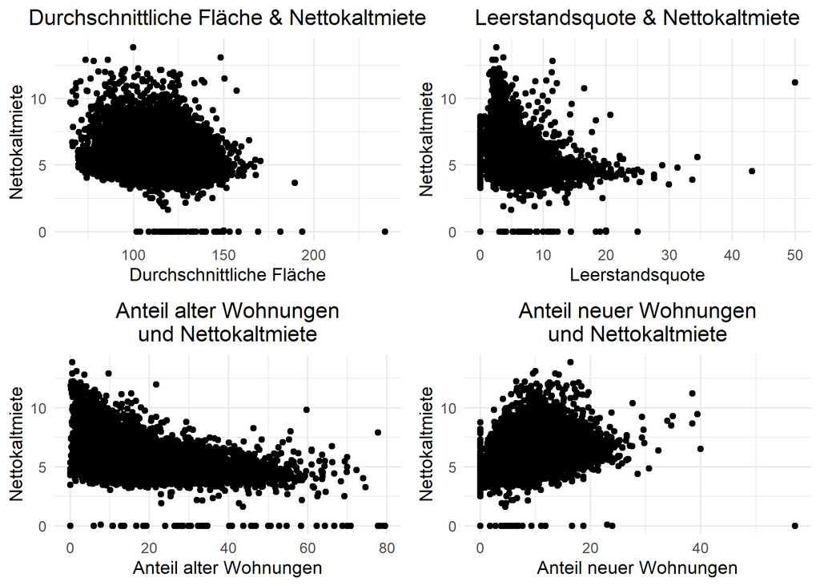

Bei der Gestaltung der Diagramme haben wir Informationen von der Seite “ggplot2.tidyverse” (https://ggplot2.tidyverse.org/reference/ggtheme.html) und vom “Cran.R-Project” (https://cran.r-project.org/web/packages/egg/vignettes/Ecosystem.html) verwendet.

Im zweiten Diagramm für die Leerstandsquote und die Nettokaltmiete ist zu sehen, dass ein negativer Zusammenhang vorliegt: Bei höherer Leerstandsquote sind die Nettokaltmieten tendenziell niedriger. Besonders bei Leerstandsquoten nahe null sind die Mieten sehr hoch, während bei Leerständen über 20 % die Mieten stark sinken. Das ist damit zu erklären, dass in Gebieten mit hoher Leerstandsquote ein Überangebot an Wohnungen besteht, was die Mietpreise senkt. Geringe Leerstände weisen hingegen auf eine hohe Nachfrage hin, was die Preise erhöht.

Danach betrachten wir das Diagramm zum Anteil alter Wohnungen und der Nettokaltmiete. Es gibt einen negativen Zusammenhang, da mit zunehmendem Anteil alter Wohnungen die Nettokaltmiete sinkt. Regionen mit einem hohen Anteil alter Wohnungen weisen niedrigere Mieten auf. Eine Erklärung ist, dass ältere Wohnungen oft weniger energieeffizient und weniger modern sind, was die Mieten gering hält.

Das letzte Diagramm zeigt den Anteil neuer Wohnungen und die Nettokaltmiete. Es besteht ein klarer positiver Zusammenhang, das heißt, Regionen mit einem hohen Anteil neuer Wohnungen haben im Durchschnitt höhere Nettokaltmieten. Das kann darauf zurückzuführen sein, dass neue Wohnungen energieeffizienter, moderner und in beliebten Stadtteilen gebaut sind, was zu höheren Mietpreisen führt.

Weiterhin wäre es von Interesse in die einzelnen Großstädte Deutschlands genauer hineinzuschauen, um dort auf Besonderheiten im Wohnmarkt einzugehen. Im ersten Schritt sollen Sie Eigenschaften in Bezug auf die Wohnungen genauer untersucht werden, um zu verstehen, welche Faktoren den Mietpreis innerhalb der urbanen Räume beeinflussen könnten. Anschließend wäre es von Interesse, auch die demografischen Merkmale der Mieterinnen und Mieter in den Blick zu nehmen. Dabei stellt sich die Frage, ob und in welchem Maße diese Einfluss auf die Mietpreise und deren Struktur nehmen.

In der vorherigen Aufgabe wurden Zusammenhänge zwischen dem Alter von Wohnungen und dem Mietpreis auf Gemeindeebene untersucht. Nun soll der Fokus darauf liegen, wie sich die Wohnungen in größeren Städten hinsichtlich ihres Alters verteilen.

8. Erstellen Sie ein Balkendiagramm für alle nachfolgenden Städte: `Stuttgart, Landeshauptstadt`, `Ulm, Universitätsstadt`, `Düsseldorf, Stadt`, `Berlin, Stadt`. Betrachten Sie dabei, wie das Alter der Wohnungen zwischen den Städten variiert. Sie sollen analysieren, wie groß der Anteil der Wohnungen abhängig nach den jeweiligen Baujahrsgruppen in den Städten ist. Tragen Sie in ihrem Balkendiagramm den *Anteil der Wohnungen nach den Baujahren* (auf der y-Achse) gegeben der *Baujahre für jede Stadt* (auf der x-Achse) ab.

Beschreiben und interpretieren Sie die Grafik. Haben Sie diese Unterschiede erwartet? Begründen Sie warum oder warum nicht.

*Hinweis:* Denken Sie daran das Faktorvariablen in ggplot hilfreich sein können.

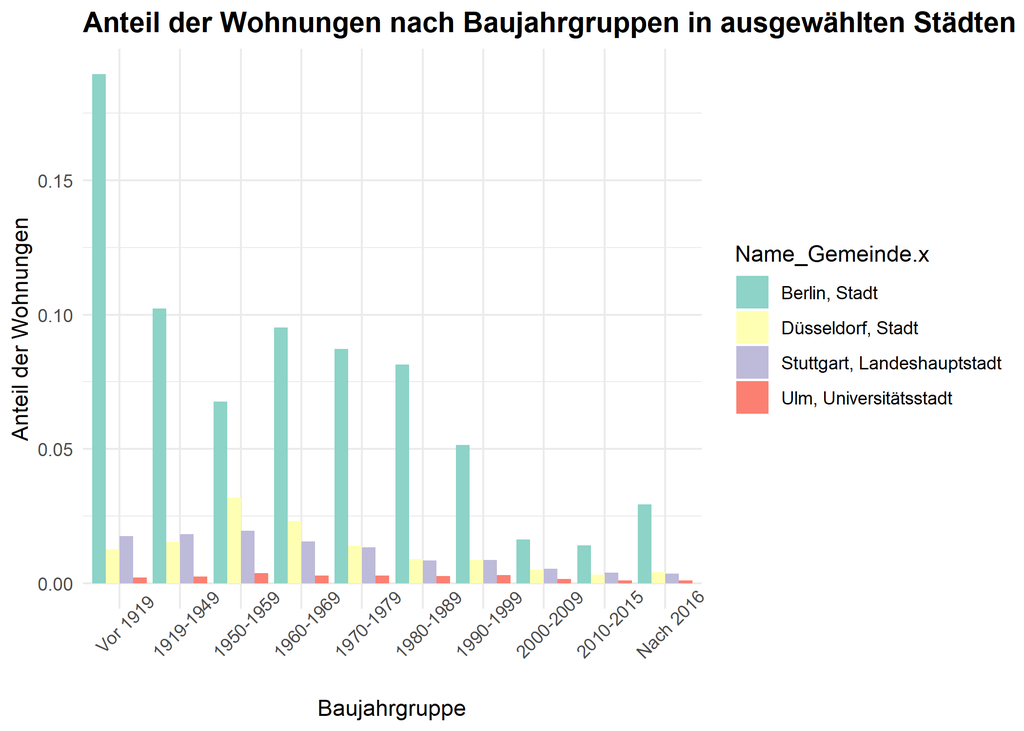

Zur Einfärbung der Grafik haben wir auf die Paletten in der “R-Graph-Gallery” zugegriffen (https://r-graph-gallery.com/38-rcolorbrewers-palettes.html).

Die Grafik zeigt den Anteil der Wohnungen in verschiedenen Baujahrgruppen für die Städte Berlin, Düsseldorf, Stuttgart und Ulm.

Berlin hebt sich in der Analyse deutlich hervor, da die Stadt die mit Abstand höchste Zahl an Wohnungen insgesamt hat. Besonders auffällig ist der hohe Anteil an sehr alten Wohnungen aus der Baujahrgruppe vor 1919. Dies spiegelt Berlins Bedeutung und lange Entwicklungsgeschichte als deutsche Hauptstadt wider, die bereits im 19. Jahrhundert und früher ein zentraler Standort war. Der signifikante Anteil an Wohnungen aus der Zeit vor 1949 betont den historischen Wiederaufbau nach dem zweiten Weltkrieg. In Stuttgart zeigt sich eine gleichmäßigere Verteilung, wobei Wohnungen aus den mittleren Baujahrgruppen stärker vertreten sind. Dies deutet darauf hin, dass Stuttgart gerade in dieser Zeit stark gewachsen ist. Ulm hat insgesamt eine gleichmäßigere, kleine Verteilung ohne deutliche Spitzen in einer bestimmten Baujahrgruppe. Stattdessen konzentriert sich der Wohnungsbestand auf die Baujahrgruppen ab 1950, was darauf hinweist, dass Ulm ein moderneres, kontinuierlich, jedoch vielleicht nicht in großen Sprüngen wachsendes Stadtbild hat. Düsseldorf ähnelt in dieser Entwicklung Stuttgart, zeigt aber tendenziell eine leichte Verschiebung hin zu moderneren Wohnungen.

Ulm hat insgesamt einen deutlich geringeren Anteil an sehr alten Wohnungen und zeigt stattdessen eine Konzentration auf modernere Baujahre, was Ulm zu einer typischen kleinen, modernen Stadt macht. Insgesamt lässt sich sagen, dass Berlin als historische Metropole viele ältere Strukturen hinsichtlich der Gebäude hat. Stuttgart und Düsseldorf zeigen den Wirtschaftsboom, was in Städten mit starker Industrialisierung typisch ist. Der Fokus auf moderne Baujahre in Ulm ist nicht überraschend, da Ulm als Universitätsstadt sehr modern ist und weniger historische Altstadtstrukturen hat. Die Unterschiede waren also weitgehend erwartbar.

9. Wie in der vorherigen Aufgabe zu sehen war, unterscheidet sich die Situation in Städten in Bezug auf die jeweiligen Baujahre der Wohnungen deutlich. Es wäre noch spannend zu sehen, ob auch das Alter der Bewohner, die Familienstände, oder die Einwanderungshistorie der Bewohner mit unterschiedlichen Mietpreisen assoziiert sind. Hier sollen Sie in einem ersten generellen Schritt ein paar demografische Faktoren einbeziehen, inwiefern diese eine Auswirkung haben. Betrachten Sie folgende Eigenschaften genauer:
- Familienstand
- Alter der Bewohner
- Einwanderungsgeschichte

Erstellen Sie eine oder mehrere passende Diagramme oder Grafiken für die in Aufgabe 8 aufgeführten Städte.

Beschreiben und interpretieren Sie diese. Haben Sie diese Unterschiede erwartet? Begründen Sie warum oder warum nicht. Wo gibt es Ihrer Ansicht nach besondere Auffälligkeiten? Warum kann es bei der unterschiedlichen Einteilung der Altersgruppen zu Problemen kommen? Was wären Möglichkeiten, um etwaige Probleme zu vermeiden?

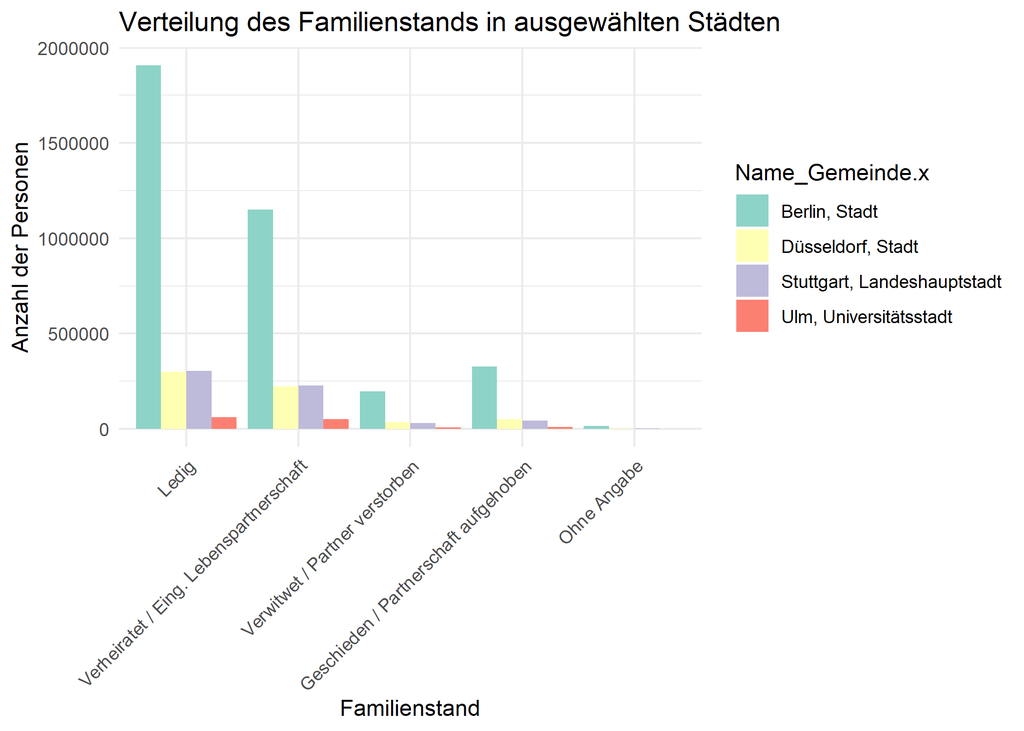

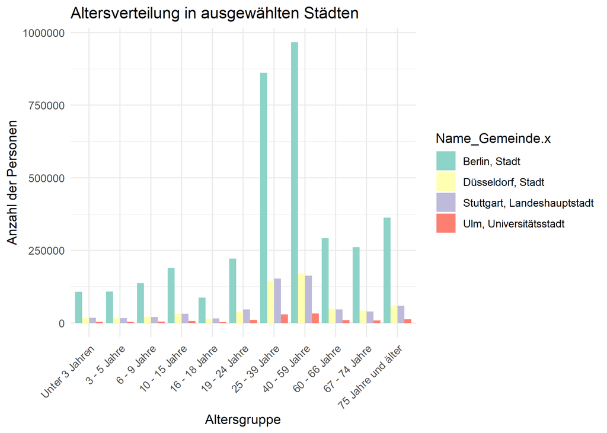

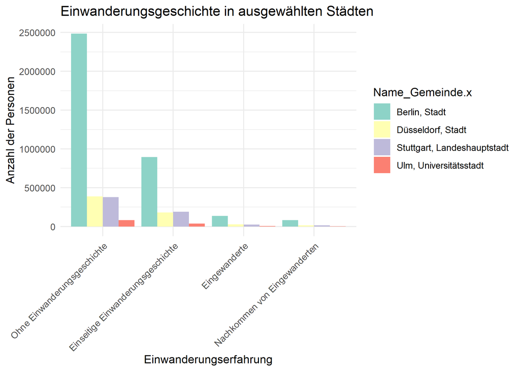

Die erste Grafik zeigt die Anzahl der Personen mit zugehörigem Familienstand in der jeweiligen Stadt. Die Personenanzahll in den jeweiligen Kategorien variiert je nach Stadt erheblich, was auf die demografischen und sozioökonomischen Unterschiede zwischen den Städten hinweist. Berlin weist eine deutlich höhere Zahl an ledigen Personen auf als alle anderen Städte. Dies ist nicht überraschend, da Berlin als größte deutsche Stadt mit einer jungen, urbanen Bevölkerung bekannt ist. Viele junge Menschen ziehen für Studium, Arbeit oder persönliche Entwicklung nach Berlin, wodurch die Kategorie “ledig” dominiert. Gleichzeitig spiegelt der geringere Anteil an verheirateten Personen die Lebensweise in einer Großstadt wider, in der traditionelle Familienstrukturen oft weniger ausgeprägt sind. Stuttgart zieht berufstätige Menschen an, die häufig in einer stabileren Lebensphase sind, was den relativ hohen Anteil an verheirateten Personen erklärt. Ulm zeigt insgesamt eine ähnliche Verteilung wie Stuttgart, allerdings auf einem niedrigeren Gesamtniveau, da Ulm eine deutlich kleinere Bevölkerung hat. Der Anteil der verheirateten Personen ist im Verhältnis ebenfalls hoch, was darauf hinweist, dass Ulm als Universitätsstadt auch Familienfreundlichkeit aufweist.

Die dritte Grafik zeigt die Verteilung der Einwanderungsgeschichte. Personen ohne Einwanderungshintergrund bilden in allen Städten die größte Gruppe, besonders dominant in Berlin. Personen mit direkter Einwanderung haben ihren größten Anteil in Berlin, das passt zu Berlins Rolle als Einwanderungszentrum Deutschlands, bedingt durch die Größe, Wirtschaftskraft und Internationalität der Hauptstadt. Stuttgart hat eine leicht höhere Anzahl an einseitig Eingewanderten als Düsseldorf. Arbeitsmigration spielte bzw spielt in Stuttgart immernoch eine große Rolle. Personen mit Eltern mit Einwanderungshintergrund sind ebenfalls in Berlin stark vertreten, während ihr Anteil in Ulm und Stuttgart deutlich geringer ist. Die höhere Diversität in Berlin war zu erwarten, da Großstädte oft als Einwanderungszentren fungieren. Ulm hat den niedrigsten Anteil, was nicht überraschend ist, da sie eine kleinere Stadt mit weniger internationalen Arbeits- und Bildungseinrichtungen ist.

In den bisherigen Analysen wurden demografische und wohnungsbezogene Faktoren in verschiedenen Städten Deutschlands untersucht. Dabei lag der Fokus darauf, wie diese Merkmale in unterschiedlichen Regionen das Mietpreisniveau und dessen Struktur beeinflussen. Aufbauend auf diesen Erkenntnissen soll der Blick nun gezielt auf den Vergleich zwischen Ost- und Westdeutschland gelenkt werden. Diese regionale Differenzierung ermöglicht es, potenzielle Unterschiede und Gemeinsamkeiten zwischen den beiden Landesteilen genauer zu analysieren. Insbesondere wird betrachtet, wie sich die Mietpreisstruktur in Ost- und Westdeutschland darstellt und ob sich hierbei spezifische Muster oder Abweichungen erkennen lassen.

10. Betrachten Sie nun die Städte `Dresden, Stadt`, `Chemnitz, Stadt`, `Stuttgart, Landeshauptstadt`, `Ulm, Universitätsstadt`,`Düsseldorf, Stadt`und `Berlin, Stadt`. Vergleichen Sie in einem ersten Schritt die Anzahl an Einwohnern, den Anteil an Menschen, die deutscher Herkunft sind, den Anteil an neuen und alten Wohnungen, sowie die durchschnittlichen Mietpreise. Erweitern Sie ihre Analyse um die durschnittlichen Wohnflächen.

Erstellen Sie für die genannten Städte eine deskriptive Tabelle. Beschreiben und interpretieren Sie diese. Beantworten Sie insbesondere folgende Fragen:

- In wie weit könnte das Alter der Wohnungen eine Rolle für den Mietpreis spielen?
- Gibt es Auffälligkeiten zwischen den einzelnen Städten in Bezug auf Herkunft der Bewohner, Einwohner und Größe der Wohnungen?
- Warum könnte es problematisch sein, wenn Sie die Städte als ein Ganzes betrachten?
- Sind Ihre Ergebnisse auf die ganze Stadt verallgemeinerbar?
- Was sind ihrer Meinung nach Faktoren, die die unterschiedlichen Mietpreise in Ost und West erklären?
- Welche Maßnahmen wären geeignet, um in Düsseldorf, Ulm und Stuttgart die Mietpreisstruktur anzupassen und bezahlbaren Wohnraum zu schaffen?

Deskriptive Statistik ausgewählter Städte

| Stadt | Einwohner | Anteil_Deutsche | Anteil_Neue_Wohnungen | Anteil_Alte_Wohnungen | Durchschnittliche_Mietpreise | Durchschnittliche_Wohnfläche |
| --- | --- | --- | --- | --- | --- | --- |
| Düsseldorf, Stadt | 611258 | 77.24 | 5.78 | 9.98 | 9.24 | 77.56 |
| Stuttgart, Landeshauptstadt | 610458 | 74.30 | 6.57 | 15.38 | 10.39 | 79.76 |
| Ulm, Universitätsstadt | 127116 | 78.22 | 9.26 | 8.72 | 8.48 | 87.64 |
| Berlin, Stadt | 3596999 | 80.46 | 5.92 | 25.79 | 7.67 | 73.22 |
| Chemnitz, Stadt | 240078 | 90.23 | 3.18 | 22.73 | 5.26 | 71.33 |
| Dresden, Stadt | 557782 | 90.69 | 6.62 | 22.72 | 6.92 | 71.24 |

Die Tabelle bietet einen Überblick über verschiedene demografische und wirtschaftliche Merkmale ausgewählter Städte in Deutschland. Sie enthält Daten zu Einwohnerzahl, Anteil der Bevölkerung deutscher Herkunft, Anteil neuer und alter Wohnungen, durchschnittliche Mietpreise und durchschnittliche Wohnfläche. Die analysierten Städte sind Dresden, Chemnitz, Stuttgart, Ulm, Düsseldorf und Berlin.

Ulm weist einen höheren Anteil neuer Wohnungen auf und hat mit durchschnittlich 87,67 m^2 die größte Wohnfläche, dennoch sind die Mietpreise dort geringer. In Universitätsstädten wie Ulm sind oft viele Wohnungen für Studierende vorgesehen. Diese Wohnungen könnten eine größere Wohnfläche haben, aber zu niedrigeren Preisen vermietet werden, um erschwinglich zu bleiben. Ebenfalls hat Ulm nicht den gleichen Status oder die gleiche Wirtschaftskraft wie größere Metropolen (z. B. Stuttgart oder Düsseldorf). Dadurch bleiben die Preise im Vergleich moderat. Evtl spielt auch der Locked -In-Effekt eine Rolle (siehe Aufgabe 15).

Die Betrachtung einer Stadt als Ganzes kann irreführend sein, da innerhalb der Städte unterschiedliche Ballungsräume mit variierenden Mietpreisen existieren, beispielsweise Stadtkern oder Industriebezirk. Obwohl allgemeine Trends erkennbar sind, können einzelne Stadtteile stark variieren; daher sollten Analysen spezifischer und detaillierter durchgeführt werden.

Die Unterschiede in den Mietpreisen zwischen Ost- und Westdeutschland sind wahrscheinlich auf historische, wirtschaftliche und politische Faktoren zurückzuführen. Nach der Wiedervereinigung zogen viele Menschen in wirtschaftlich attraktivere westdeutsche Städte, was im Osten zu einem Bevölkerungsrückgang und damit teilweise sinkenden Mietpreisen führte. Westdeutsche Städte bleiben auch heute noch attraktiver für die junge Generation, profitieren von einer stärkeren wirtschaftlichen Basis mit höheren Gehältern, mehr Beschäftigungsmöglichkeiten und besseren Karrierechancen. Diese Faktoren führen zu einer höheren Nachfrage nach Wohnraum und folglich höheren Mietpreisen.

Um die Mietpreise in Städten wie Düsseldorf, Ulm und Stuttgart anzupassen, könnte die Politik Maßnahmen wie die Einführung einer Mietpreisbremse in Erwägung ziehen. Zudem würde die Förderung von Neubauten zusätzlichen Wohnraum schaffen, was langfristig die Preise senken könnte. Die Unterstützung von genossenschaftlichen Wohnprojekten und Investitionen in den sozialen Wohnungsbau sind ebenfalls geeignete Maßnahmen, um bezahlbaren Wohnraum zu schaffen. Auch Investitionen in den Nahverkehr könne sinnvoll sein, damit mehr Menschen ins günstigere Umland ziehen können, ohne ihre Arbeitsplätze in der Stadt zu verlieren.

11. Lesen Sie den [folgenden Artikel](https://www.tagesschau.de/wirtschaft/sozialwohnungen-bau-mangel-101.html). Dort werden Sozialwohnungen thematisiert, warum so viele fehlen und wer davon vor allem betroffen ist. Beantworten Sie anschließend folgende Fragen:
- Welche Bevölkerungsgruppen sind am stärksten von der Sozialwohnungsnot betroffen und inwiefern?
- Was sind Gründe, warum es zu wenige Sozialwohnungen gibt?
- Wie sieht die historische Entwicklung des Sozialwohnungsbaus aus, im Hinblick auf Vorhandensein von Wohnungen und Investitionen in den Bau von neuen Wohnungen?
- Welche Anreize könnten Investoren motivieren, mehr Sozialwohnungen zu bauen?
- Welche innovativen Ansätze können Bauherren verfolgen, um die Kosten für den Wohnungsbau zu senken?

Der Mangel an Sozialwohnungen betrifft besonders die finanziell schwächeren Bevölkerungsgruppen, die sich auf dem normalen Wohnungsmarkt keine bezahlbare Wohnung leisten können. Diese Gruppen befinden sich oft auf langen Wartelisten, selbst wenn sie über einen Wohnberechtigungsschein verfügen, denn das Angebot an Sozialwohnungen ist extrem knapp.

Die Gründe für den Mangel an Sozialwohnungen in Deutschland sind vielschichtig. Ein wesentlicher Faktor sind die gestiegenen Baukosten und Darlehenszinsen, die den Neubau von Wohnungen erheblich verteuern. Darüber hinaus herrscht ein Mangel an Fachkräften im Baugewerbe, was die Bauprozesse verlangsamt. Auch historisch betrachtet hat sich die Anzahl der Sozialwohnungen drastisch verringert. Diese Reduzierung hat verschiedene Ursachen, darunter das Auslaufen von Mietbindungen und fehlende Investitionen in Neubauten.

Die historische Entwicklung des Sozialwohnungsbaus ist von einem Rückgang der vorhandenen Sozialwohnungen und einer stagnierenden Investitionsbereitschaft geprägt. In den vergangenen Jahrzehnten ist die Zahl der zur Verfügung stehenden Sozialwohnungen kontinuierlich gesunken, während die Nachfrage nach bezahlbarem Wohnraum gestiegen ist. Dies hat zu einem kritischen Engpass im Angebot geführt, der weiterhin besteht.

Um Investoren zu motivieren, in den Bau von Sozialwohnungen zu investieren, könnten verschiedene Anreize geschaffen werden. Dazu gehören erhöhte staatliche Fördergelder, die Investitionen erleichtern würden, sowie steuerliche Erleichterungen für Unternehmen, die erschwinglichen Wohnraum schaffen. Ein weiterer Lösungsansatz könnte die Vereinfachung von Baugenehmigungen sein, wodurch Projekte schneller und kostengünstiger realisiert werden könnten.

Neben staatlichen Maßnahmen können auch Bauherren innovative Ansätze verfolgen, um die Baukosten zu senken. Der Einsatz effizienter Baumethoden kann dazu beitragen, die Baukosten zu reduzieren. Diese Maßnahmen könnten nicht nur Kosten sparen, sondern auch den Bauprozess beschleunigen, was letztlich zu einem schnelleren Ausbau des verfügbaren Wohnraums führen würde. So könnte mit weniger Materialeinsatz und durch den Einsatz kosteneffektiver Bauweisen der Bauprozess optimiert werden.

Insgesamt ist klar, dass sowohl staatliche Interventionen als auch Innovationen im Bauprozess notwendig sind, um den gegenwärtigen Mangel an Sozialwohnungen zu beheben. Die Lösung liegt sowohl in der Bereitschaft der Politik, umfassende Förderprogramme zu gestalten, als auch in der Bauwirtschaft, bezahlbaren Wohnraum effizient zu realisieren. Die Herausforderung besteht darin, ein Gleichgewicht zwischen den finanziellen Interessen der Investoren und den sozialen Bedürfnissen der Bevölkerung zu finden, um den Wohnungsbau nachhaltig zu verbessern.

12. Gerade die Politik ist gefordert, bezahlbaren Wohnraum zu realisieren. Dabei gibt es eine Viezahl an politischen Maßnahmen, die aufgestellt wurden und umfangreich diskutiert werden. Betrachten Sie die folgenden Maßnahmen, welche helfen sollen, die angespannte Lage auf dem Mietmarkt zu entlasten. Argumentieren Sie, warum diese Maßnahmen sinnvoll/nicht sinnvoll sind und in welcher Art und Weise diese umgesetzt werden können.
1. “Fachleute fordern, die Regulierung von Bestandsmieten zu lockern, damit sich ihr Niveau den Neuvertragsmieten annähert, mehr Menschen umziehen und sich Wohnraum besser verteilt.”
2. “Eine weitere Möglichkeit wäre, Mieterhöhungen bei Neuvertragsmieten zu begrenzen.”
3. “Am einfachsten ist es, wenn vor allem in Großstädten, wo bezahlbarer Wohnraum fehlt, mehr gebaut wird.”
4. “Am besten wäre es, wenn zukünftig mehr Vermieter in regelmäßigen Abständen die Miete anpassen.”

Um die angespannte Lage auf dem Mietmarkt zu entschärfen, stehen folgende Maßnahmen im Raum, die diskutiert werden sollen:

1. Lockerung der Regulierung von Bestandsmieten:

Fachleute fordern, die Regulierung von Bestandsmieten zu lockern, damit sich deren Niveau den Neuvertragsmieten annähert. Diese Maßnahme könnte dazu führen, dass der Wohnraum effizienter verteilt wird, da mehr Menschen motiviert sein könnten, umzuziehen. Gleichzeitig könnte es jedoch bestehende Mieter, insbesondere jene mit niedrigerem Einkommen, finanziell stärker belasten, da diese verdrängt werden könnten. Eine mögliche Umsetzung bestünde darin, die Erhöhungen gestaffelt einzuführen, um eine plötzliche finanzielle Gefährdung der Mieter zu vermeiden. Eventuell wäre hier auch eine Kombination mit umfassendem sozialen Wohnungsbau und zusätzlichen Förderprogrammen für einkommensschwache Haushalte sinnvoll.

2. Begrenzung von Mieterhöhungen bei Neuvertragsmieten:

Eine weitere Möglichkeit wäre, Mieterhöhungen bei Neuvertragsmieten zu begrenzen, um extrem hohe Mietsteigerungen zu verhindern. Diese Maßnahme könnte helfen, den Zugang zu Wohnraum zu stabilisieren. Allerdings besteht das Risiko, dass der Markt dadurch weniger attraktiv für Investitionen wird, was zu weniger Vermietern führen könnte und letztlich das Wohnungsangebot negativ beeinflussen könnte. Die Umsetzung könnte durch gesetzliche Obergrenzen erfolgen.

3. Mehr Wohnungsbau in Großstädten:

Am einfachsten scheint es, mehr Wohnraum zu bauen, speziell in Großstädten, wo der Bedarf am größten ist. Der Bau neuer Wohnungen würde das Angebot direkt erhöhen und dabei helfen, das niedrige Angebot zu steigern. Allerdings sind Bauprojekte langwierig und die Verfügbarkeit geeigneter Flächen ist oft begrenzt. Außerdem sind die aktuell sehr hohen Baukosten oft ein Hindernis. Die Förderung von Bauprojekten könnte durch staatliche Subventionen und die Bereitstellung von günstigeren Baugrundstücken erfolgen. Zudem könnte die Bürokratie bei der Vergabe von Baugenehmigungen vereinfacht und beschleunigt werden, um den Bauprozess zu verkürzen.

4. Regelmäßige Mietanpassungen durch Vermieter:

Regelmäßige Mietanpassungen könnten es Vermietern ermöglichen, Kostensteigerungen gleichmäßiger zu verteilen und die Wohnungen instand zu halten. Jedoch wären auch unkontrollierte Mietsteigerungen denkbar. Bestimmte Gesetze für Anpassungen und deren Kontrolle könnten dazu beitragen, überproportionale Erhöhungen zu verhindern.

Insgesamt zeigt sich, dass keine dieser Maßnahmen allein die Probleme auf dem Mietmarkt auf Dauer lösen kann. Vielmehr ist es notwendig, eine Kombination von Maßnahmen zu ergreifen, die sowohl kurzfristige Entlastungen für Mieter als auch langfristige Lösungen wie den Ausbau des Wohnungsbaus und die Förderung von sozialem Wohnungsbau umfasst. Ein Ansatz, der sowohl wirtschaftliche als auch soziale Aspekte berücksichtigt, wäre nötig, um bezahlbaren Wohnraum sicherzustellen.

# Einzelne Stadtteile in Deutschland

In allen vorherigen Aufgaben haben Sie die Städte, Gemeinden oder auch Landkreise immer als ein Ganzes betrachtet. Jedoch ist es schwierig gerade in Großstädten wie Berlin, Düsseldorf oder auch Stuttgart allgemeine Aussagen über die Mietsituation auf Stadtebene zu treffen. Dies liegt unter anderem daran, dass unterschiedliche Stadtviertel unterschiedliche demografische Eigenschaften, sowie eine unterschiedliche Mietstruktur aufweisen können. Hier wäre es sinnvoll sich mit dem Stadtbild und der Verteilung der Mieten genauer auseinanderzusetzen, um zu sehen, wie sich Mieten innerhalb der Stadt verteilen. Wie in Aufgabe 10 zu sehen war, weisen die Städte im Westen Deutschlands untereinander, sowie die Städte im Osten ähnliche Merkmale auf, weshalb Sie sich in den folgenden Aufgaben auf je eine große und eine kleinere Stadt aus beiden Regionen konzentrieren.

13. In dieser Aufgabe sollen Sie ihren Datensatz aus Aufgabe 4, bei dem Sie Kartendaten und Informationen zu Mieten und LEQ auf 1km-Gitterebene heruntergeladen und zusammengefügt haben, verwenden und vier Karten zeichnen, welche die Verteilung der Nettokaltmieten in den Stadtteilen der Städte “Stuttgart, Landeshauptstadt”, “Ulm, Universitätsstadt”, “Chemnitz, Stadt” und “Dresden, Stadt” anschaulich visualisieren.

Erstellen Sie vier Grafiken, beschreiben und interpretieren diese. Gehen Sie insbesondere auf folgende Fragen ein:

- Welche Besonderheiten fallen Ihnen bei diesen Städten auf?
- Gibt es eine Segregation in Bezug auf die Mieten in einzelnen Stadtteilen?
- Falls es eine Segregation gibt, welche Konsequenzen könnte dies haben?
- Welche Rolle spielen geografische oder infrastrukturelle Faktoren bei den Mietpreisen?
- Gibt es Unterschiede zwischen Städten im Osten und Westen Deutschlands, falls ja, welche Einflüsse in Bezug auf Wirtschaft und Arbeitsmarkt könnte dies in den jeweiligen Städten haben?

*Hinweis:* Wenn Sie einheitliche Legenden für die Karten haben möchten und die vier Städte nebeneinander oder untereinander darstellen wollen, so empfiehlt sich das Paket `ggpubr` und dort der Befehl `ggarrange`.

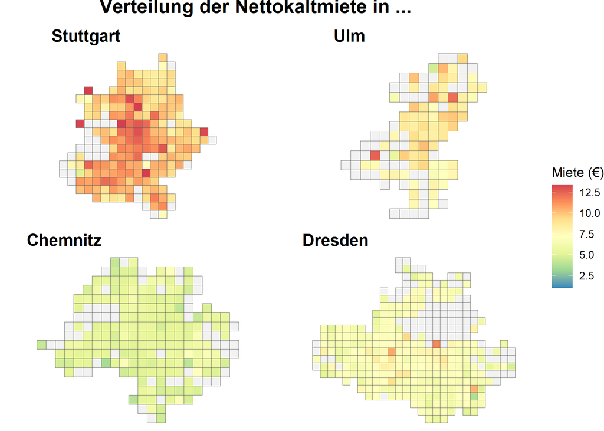

Zur Ideensammlung für die Gestaltung der Karten haben wir die R-Craft-Gallery genutzt. (https://r-graph-gallery.com/79-levelplot-with-ggplot2.html) (https://r-graph-gallery.com/package/sf.html)

Die Farbskala unterscheidet dabei nur zwischen Werten bis zum 99%-Quantil der Mieten, um das Bild nicht durch Ausreißer zu verzerren. Das heißt Mieten, die höher als 13.361 EUR/qm sind, werden alle mit der Maximalfarbe dargestellt.

Quantile der durchschnittlichen Miete pro Quadratmeter

| Quantil | Wert |
| --- | --- |
| 0% | 1.00 |
| 99% | 13.36 |

BESCHREIBUNG:

Beim Betrachten der Grafiken fällt zunächst auf, dass die Nettokaltmieten in Stuttgart im Allgemeinen deutlich höher sind als in den anderen drei Gemeinden. In absteigender Reihenfolge, bezogen auf die Miethöhen, folgt auf Stuttgart Ulm, danach Dresden und zuletzt Chemnitz.

Analysiert man die interne Verteilung der Miethöhen jeder Gemeinde, so ist in Stuttgart deutlich zu erkennen, dass die Höhe der Mietpreise zum Zentrum hin zunimmt, wohingegen sie an den Randbereichen der Gemeinde etwas niedriger sind. In den anderen drei Städten lässt sich kein solches Muster erkennen. Jedoch ist zu sehen, dass die Mieten in Ulm eine größere Bandbreite im Vergleich zu den beiden ostdeutschen Gemeinden aufweisen, in denen sie einheitlicher zu sein scheinen. Ausgenommen sind hierbei vereinzelte Gebiete in Dresden, die sich stark vom Rest unterscheiden.

INTERPRETATION:

Da die Grafiken jeweils ein ländliches und ein zentraleres Gebiet in Ost- und Westdeutschland abbilden, sind folgende Schlüsse abzuleiten:

Besonders in Stuttgart zeigt sich eine starke Segregation der Mietpreise, ebenso leicht in Dresden. Dies legt nahe, dass besonders in Großstädten ärmere Bevölkerungsschichten an den Stadtrand gedrängt werden (siehe Stuttgart) oder zumindest in bestimmten besonders beliebten Vierteln nicht präsent sind (siehe Dresden).

Diese Segregation fördert als Konsequenz die Zunahme der gesellschaftlichen Spaltung in Großstädten. Durch die Bewohnung der am günstigsten gelegenen Gebiete durch die wohlhabenderen Schichten profitieren diese am meisten von den Chancen, die diese bieten. Dagegen haben Menschen, die diese Chancen dringender benötigen, keinen Zugang, was ihnen einen sozialen Aufstieg zusätzlich erschwert.

Die Beliebtheit verschiedener Viertel bestimmt sich insbesondere durch geografische und infrastrukturelle Merkmale. Einerseits ist die absolute Nähe zu wichtigen alltäglichen Zentren wie der Innenstadt, Bildungseinrichtungen, industriellen Zentren, Geschäftszentren oder großen Arbeitgebern ausschlaggebend. Andererseits spielt besonders die Anbindung zu diesen Zentren sowie die Vernetzung mit öffentlichen Verkehrsmitteln eine entscheidende Rolle. Ebenso sind die Einkaufsmöglichkeiten und das Angebot an öffentlichen Dienstleistungen in direkter Nähe relevant.

Diese Faktoren fallen meist in Zentrumsnähe zusammen, wobei jedoch ländlichere Regionen wie Chemnitz weniger von einem dominanten Stadtzentrum geprägt sind. Ulm bildet wahrscheinlich wegen seiner kleinen Größe und seiner Rolle als Universitätsstadt sowie in der Industrie eine Ausnahme.

14. Nachdem Sie in Aufgabe 13 die Verteilung der Mieten der einzelnen Stadtteile visualisiert haben, sollten Sie in dieser Aufgabe den Anteil der Leerstandsquoten in den Stadtteilen der Städte “Stuttgart, Landeshauptstadt”, “Ulm, Universitätsstadt”, “Chemnitz, Stadt” und “Dresden, Stadt” veranschaulichen.

Erstellen Sie vier Grafiken, beschreiben und interpretieren diese. Gehen Sie insbesondere auf folgende Fragen ein:

- Was könnten Gründe sein, dass die Leerstandsquote in bestimmten Stadtteilen höher ist, als in anderen?
- Welche Besonderheiten fallen Ihnen bei diesen Städten auf? Auch im Hinblick auf ihre Erkenntnisse aus Aufgabe 13.
- Vergleichen Sie die Grafiken aus Aufgabe 13 und Aufgabe 14. Was könnte der Grund für die unterschiedlichen Muster sein?
- Welche Maßnahmen ergreifen Städte mit hohen Leerstandsquoten, um diese zu reduzieren?

*Hinweis:* Wenn Sie einheitliche Legenden für die Karten haben möchten und die vier Städte nebeneinander oder untereinander darstellen möchten, so empfiehlt sich das Paket `ggpubr` und dort der Befehl `ggarrange`.

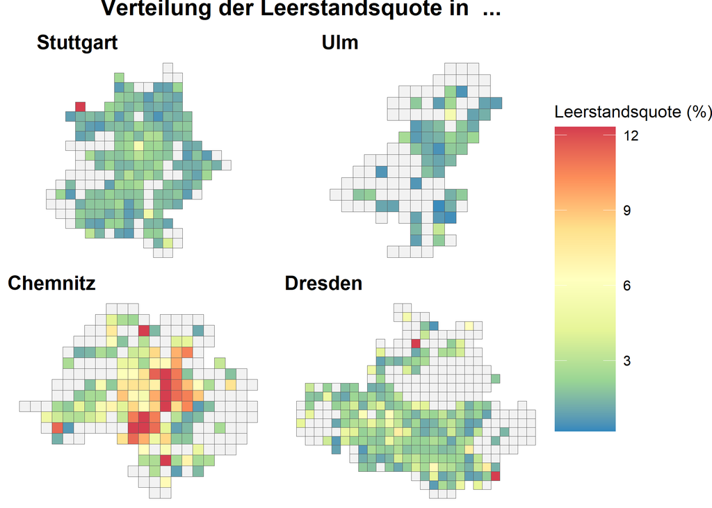

In dieser Grafik ist die Verteilung der Leerstandsquoten in denselben Städten aus Aufgabe 13 abgebildet, das sind Stuttgart, Ulm, Dresden und Chemnitz.

Wie in Aufgabe 13 basiert die Farbskala auf den Werten bis zum 99%-Quantil der Leerstandsquoten.

Quantile der Leerstandsquote

| Quantil | Wert |
| --- | --- |
| 0% | 0.18 |
| 99% | 12.31 |

BESCHREIBUNG:

Zunächst fällt auf, dass die vier Gemeinden bezüglich der Leerstandsquoten in umgekehrter Reihenfolge aufeinander folgen, bezogen auf die vorher beobachteten Mietpreise. Die größten Leerstandsquoten weist hierbei mit Abstand Chemnitz auf, das einen Ruf als besonders ländliches Gebiet hat. Dieses wird gefolgt von Dresden, und zuletzt Ulm und Stuttgart, wobei letztere beiden ähnliche Quoten aufweisen.

Intern weist Chemnitz ein deutliches Muster in der Verteilung auf, dessen Leerstandsquoten zum Zentrum hin stark zunehmen. In den anderen Gemeinden dagegen scheinen die Leerstandsquoten eher gleichmäßig verteilt zu sein, mit Ausnahme vereinzelter Zellen in Dresden und Stuttgart.

Beide ostdeutschen Gemeinden weisen ebenfalls allgemein eine höhere Bandbreite an Leerstandsquoten auf als die beiden westdeutschen.

INTERPRETATION:

Die Tatsache, dass einige Stadtteile höhere Leerstandsquoten aufweisen als andere, könnte auf verschiedene Ursachen zurückzuführen sein.

Einerseits spielt, wie bei den Mietpreisen, die Attraktivität der Lage durch Infrastruktur, Vernetzung und Zentrumsnähe eine Rolle. Andererseits können die Ursachen auch in Gegebenheiten wie Verfall oder demografischem Wandel liegen. Besonders Gemeinden aus der ehemaligen DDR besitzen häufig renovierungsbedürftige Gebäude aus jener Zeit, die mit der sozialistischen Wohnpolitik nicht instand gehalten wurden und nun, nicht zuletzt wegen der schwächeren Wirtschaftslage vieler Oststädte, für Investoren unattraktiv sind. Auch der Staat hält sich diesbezüglich zurück. Ländliche Gegenden sind dagegen besonders mit einem demografischen Wandel konfrontiert, da sie für jüngere Bevölkerungsgruppen meist weniger attraktiv sind, was dafür sorgt, dass deren Einwohnerzahlen stetig sinken.

Da die Leerstandsquote als Indiz für die Nachfrage gesehen werden kann, legt der Vergleich nahe, dass eine hohe Nachfrage der bestimmende Faktor für die Mietpreise auf dem Markt ist. Das schließt daher, dass der Wohnungsmarkt die Besonderheit aufweist, dass das Angebot nicht oder nur sehr beschränkt angepasst werden kann.

Maßnahmen, die Städte ergreifen, um hohe Leerstandsquoten zu reduzieren, basieren zum einen auf Zuschüssen zur Förderung von Renovierungsarbeiten, andererseits könnte auch ein Ausbau der Infrastruktur in ländlichen Gebieten hilfreich sein, um solche Standorte attraktiver zu machen.

15. Die aktuellen Mietpreise und deren Entwicklungen hindern in Deutschland immer mehr Menschen daran, dass sie sich eine neue geeignete Wohnung suchen. Personen, die aufgrund ihrer aktuellen Lebenssituation sich nach einer neuen Wohnung umsehen, finden oft keine oder können sich diese nicht leisten. Doch worin liegen die Ursachen und Probleme?

Beantworten Sie hierzu folgende Fragen:

- Was versteht man unter dem Lock-in-Effekt, speziell in Bezug auf den Mietmarkt? Wer ist davon vor allem betroffen und warum?
- Gibt es aktuell Möglichkeiten, die vor allem diese “betroffenen” Personen haben, um an bezahlbaren Wohnraum zu gelangen?
- Worin liegen die Ursachen, dass Bestandsmieten (Mieten aus bestehenden Verträgen) und Angebotsmieten (Mieten aus Neuverträgen) so stark voneinander abweichen?

Gehen Sie in ihrer Argumentation auch auf die Grafiken und Ergebnisse der Aufgaben 11, 13 und 14 ein.

Die aktuellen Entwicklungen auf dem Mietmarkt in Deutschland stellen viele Menschen vor große Herausforderungen. Zunächst ist der Lock-in-Effekt ein zentrales Problem auf dem Mietmarkt. Er tritt auf, wenn Mieter trotz veränderter Lebensumstände in ihren alten Wohnungen verbleiben, da die Mieten für neue Wohnungen deutlich höher sind als die aktuelle Bestandsmiete. Besonders betroffen sind einkommensschwache Haushalte, ältere Menschen und Familien. Diese Gruppen können sich die deutlich gestiegenen Angebotsmieten oft nicht leisten und vermeiden deshalb einen Umzug, auch wenn ihre jetzige Wohnung nicht mehr ihren Bedürfnissen entspricht. Dadurch wird der Wohnungsmarkt unflexibel, und es entsteht ein Mangel an frei verfügbaren und bezahlbaren Wohnungen.

Für diese betroffenen Personen gibt es nur wenige Möglichkeiten, an bezahlbaren Wohnraum zu gelangen. Eine Option sind Sozialwohnungen, die speziell für einkommensschwache Haushalte vorgesehen sind. Allerdings ist das Angebot an Sozialwohnungen stark begrenzt, wie in Aufgabe 11 erläutert wurde. Viele Menschen mit Wohnberechtigungsschein stehen auf langen Wartelisten, da nicht genug Wohnungen zur Verfügung stehen. Darüber hinaus können Förderprogramme wie Wohngeld oder kommunale Wohnungsunternehmen helfen, da sie oft günstigeren Wohnraum anbieten. Diese Alternativen sind jedoch ebenfalls begrenzt und können die Wohnungsnot nur bedingt lindern.

Ein weiteres Problem des Mietmarkts liegt, wie erwähnt, in der starken Abweichung zwischen Bestandsmieten und Angebotsmieten. Bestandsmieten sind oft durch langfristige Mietverträge und gesetzliche Regelungen wie die Mietpreisbremse gedeckelt. Dies schützt Mieter vor übermäßigen Mietsteigerungen, solange sie in derselben Wohnung bleiben. Angebotsmieten hingegen orientieren sich an der aktuellen Marktsituation und steigen aufgrund von hoher Nachfrage und knappem Angebot stark an. Dies führt dazu, dass neue Mietverträge häufig um ein Vielfaches teurer sind als bestehende.

Die Ergebnisse aus Aufgabe 14 ergänzen diese Analyse, da die Leerstandsquote in den Städten ebenfalls eine Rolle spielt. In Stuttgart und Ulm sind die Leerstandsquoten niedrig, was auf eine hohe Nachfrage nach Wohnraum und eine geringe Verfügbarkeit hinweist. In Dresden und Chemnitz hingegen gibt es höhere Leerstandsquoten. Dennoch steigen die Mieten in diesen Städten, besonders in den zentralen Bereichen, was darauf hinweist, dass auch hier die Nachfrage das Angebot übersteigt, aber die hohen Neu-Mieten für viele Gruppen nicht bezahlbar sind.

Zusammenfassend lässt sich sagen, dass der Lock-in-Effekt, die hohe Differenz zwischen Bestands- und Angebotsmieten sowie die geografische Ungleichheit in den Mietpreisen zu einer wachsenden Wohnungsnot führen. Besonders betroffene Gruppen haben derzeit nur wenige Möglichkeiten, an bezahlbaren Wohnraum zu gelangen. Die Lösung dieser Probleme erfordert sowohl staatliche Interventionen als auch Neuerungen im Wohnungsbau, um den Mietmarkt gerechter und flexibler zu gestalten.

# Stadt vs. Land

Bisher haben Sie sich intensiv mit der Wohnsituation in Deutschland auseinandergesetzt und dabei insbesondere die Unterschiede zwischen Ost- und Westdeutschland betrachtet. Im Fokus standen dabei die Mietpreisentwicklung und die Rolle verschiedener Faktoren wie demografische Merkmale, Leerstandsquote, Eigentümerquote, sowie die Wohnfläche. Diese Analysen haben wertvolle Erkenntnisse über die regionale Dynamik des Mietmarkts geliefert.

Nun sollen Sie ihren Blickwinkel erweitern und den Fokus auf eine weitere Ebene der Analyse richten. Im Kern sollen Sie den Unterschied zwischen städtischen Regionen, insbesondere Großstädten, und ländlichen Gebieten untersuchen. Hierbei soll die Mietstruktur in diesen beiden Raumtypen analysiert werden, ob sich die Strukturen von Stadt und Land voneinander unterscheiden.

16. Betrachten Sie in einem ersten Schritt die Wohnungen abhängig ihres Alters. Erstellen Sie dazu eine passende Grafik, die die Verteilung der Wohnungen nach Altersgruppen für die Stadt `Stuttgart, Landeshauptstadt` (Landkreis: Stuttgart, Stadtkreis) im Vergleich zum `Alb-Donau-Kreis` und `Ostalbkreis` darlegt.

Beschreiben und interpretieren Sie ihre Grafik. Woran könnte es liegen, dass es in Stuttgart (in der Stadt) deutlich mehr Altbauwohnungen als auf dem Land gibt? Könnten politische Maßnahmen ihrer Ansicht nach helfen, dass auch in Großstädten mehr neue Wohnungen erbaut und zur Vermietung zur Verfügung gestellt werden?

*Hinweis 1:* Nutzen Sie für die Visualisierung einen Mosaik- oder ein “stacked” Balkendiagramm. Eine Idee, wie Sie das Ganze darstellen können, finden Sie [hier](https://r-graph-gallery.com/).

*Hinweis 2:* Für Stuttgart soll der komplette Landkreis (“Stadtkreis”) untersucht werden.

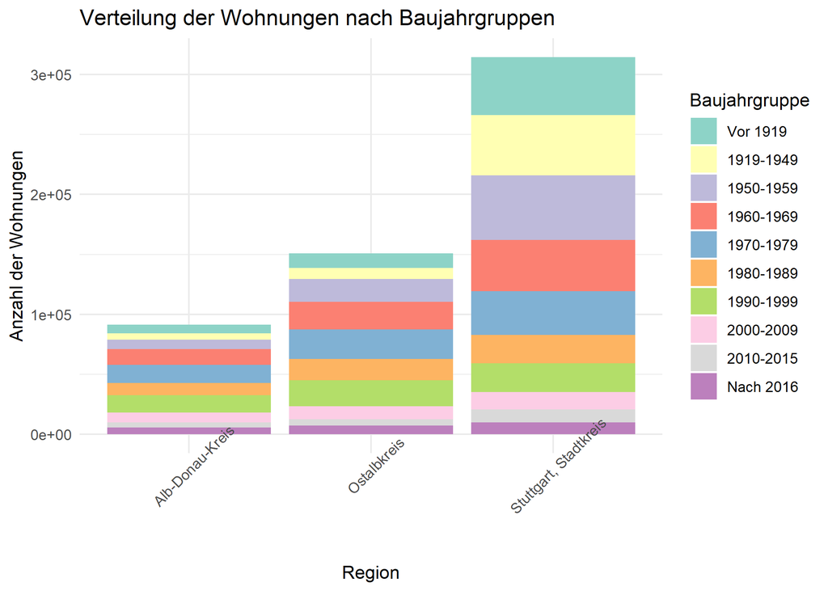

Möchte man die Grafik interpretieren, so lässt sich sagen, dass die vermehrten Altbauten in Stuttgart darauf zurückzuführen sein könnten, dass sich die Großstadt durch die historische Entwicklung viele Gebäude aus früheren Jahrzehnten erhalten hat, die weiterhin genutzt werden. Hier könnte sich der Wohnungsbau stärker auf das 19. und frühe 20. Jahrhundert konzentriert haben. Zudem gibt es in Großstädten weniger verfügbare Flächen für Neubauten. Daher werden Altbauten oft saniert. In ländlichen Regionen ist mehr Fläche für neue Bauprojekte verfügbar. Zudem gibt es weniger historische Gebäude, sodass neue Wohnungen notwendig sind, um den Wohnbedarf zu decken.

Politische Maßnahmen könnten dabei helfen, den Neubau in Großstädten wie Stuttgart zu fördern, beispielsweise Subventionen oder steuerliche Vorteile für den Neubau von Wohnungen. Auch verstärkte Investitionen in den sozialen Wohnungsbau, um bezahlbaren Wohnraum zu schaffen und den Druck auf den Wohnungsmarkt zu reduzieren, wären sinnvoll. Jedoch könnten hier auch Hindernisse auftreten, beispielsweise fehlende Flächen für Neubauten in Großstädten wie Stuttgart oder hohe Grundstückspreise, was es für mögliche Mieter oft zu teuer macht.

Zu den neuen Wohnungen wurden dabei alle Wohnungen gezählt, die ab 2010 gebaut wurden, zu den alten Wohnungen diejenigen, die vor 1950 gebaut wurden, und zu den mittelalten Wohnungen alle Wohnungen mit Baujahr zwischen 1950 und 2009.

In einem weiteren Schritt sollen Sie nun die Mietpreise und deren Verteilung analysieren. Hierbei sollen Sie neben der Leerstands- und Eigentümerquote auch auf die Verteilung der Wohnungen nach deren Wohnfläche achten und diese untersuchen.

17 (a). Erstellen Sie zuerst eine Tabelle, die die durchschnittlichen Mietpreise mit der Leerstands- und Eigentümerquote darstellt. Was fällt ihnen dabei besonders auf? Beschreiben und interpretieren Sie ihre Tabelle.

17 (b). Erstellen Sie eine weitere Grafik, die die Verteilung der Wohnungen nach den einzelnen Wohnungsgrößen(<40m² bis >=200m²) abbildet. Stellen Sie darüber hinaus den durchschnittlichen Mietpreis je Landkreis in einer weiteren Grafik dar. Beschreiben und interpretieren Sie ihre Grafiken. Gehen Sie insbesondere auf die Frage ein, ob es Sinn macht sich vor allem den Ostalbkreis oder Alb-Donau-Kreis als ein Ganzes anzusehen und inwieweit überhaupt ein Vergleich zwischen Stadt und ländlicher Region möglich ist.

*Hinweis:* Hier sollen Sie erneut auf dieselben Städte und Landkreise aus Aufgabe 16 eingehen!

Vergleich der Durchschnittsmieten pro Landkreis mit deren Eigentümer- und Leerstandquote

| Landkreis.x | Durchschnittsmiete | LEQ | ETQ |
| --- | --- | --- | --- |
| Ostalbkreis | 6.27 | 5.09 | 70.59 |
| Alb-Donau-Kreis | 6.37 | 5.34 | 71.44 |
| Stuttgart, Stadtkreis | 10.39 | 3.46 | 31.15 |

In dieser Tabelle sind die durchschnittlichen Mietpreise der zuvor analysierten Landkreise in EUR pro Quadratmeter sowie die jeweiligen Eigentümer- und Leerstandsquoten aufgelistet. Dabei ist diese aufsteigend nach Durchschnittsmietpreis geordnet. Auffällig ist, dass Stuttgart, als wirtschaftlich und kulturell bedeutendste Stadt der Region, den höchsten Durchschnittsmietpreis aufweist. Im Gegensatz dazu verzeichnen die beiden ländlicheren Kreise deutlich niedrigere Mietpreise.

Es ist eine Tendenz zu erkennen, dass höhere Mietpreise mit niedrigeren Eigentümer- und Leerstandsquoten einhergehen.

Insbesondere weisen der Ostalbkreis und der Alb-Donau-Kreis, die Durchschnittsmieten von 6,3 bzw. 6,4 EUR/qm besitzen, relativ hohe Eigentümerquoten von ca. 71 % und Leerstandsquoten von etwa 5 % auf. Im Gegensatz dazu besitzt die Großstadt Stuttgart mit einem Mietpreis von 10,4 EUR/qm eine kaum halb so hohe Eigentümerquote von 31 % und eine Leerstandsquote von lediglich 3,5 %.

Diese Beobachtungen festigen die These, dass die Höhe der Nachfrage einen entscheidenden Einfluss auf die Mietpreise hat. Hohe Eigentümer- und Leerstandsquoten gelten als Indikatoren für eine geringere Nachfrage. Gleichzeitig ist bekannt, dass Groß- und Universitätsstädte durch eine besonders hohe Wohnungsnachfrage geprägt sind, was sich in den Mietpreisen widerspiegelt.

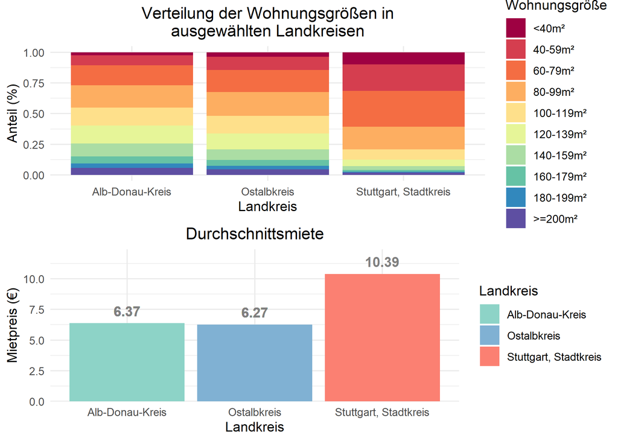

Die beiden Grafiken zeigen für die Landkreise Alb-Donau-Kreis, Ostalbkreis und Stuttgart einerseits die Verteilung der Wohnungen nach ihrer Fläche und andererseits den durchschnittlichen Mietpreis in den jeweiligen Kreisen.

Betrachtet man die Verteilung der Wohnflächen in den drei ausgewählten Landkreisen, so fällt ins Auge, dass in den ländlicheren Kreisen Ostalbkreis und Alb-Donau-Kreis große Wohnungen, insbesondere ab einer Fläche von 100 Quadratmetern, deutlich stärker vertreten sind als in Stuttgart. In den beiden ländlichen Kreisen machen diese Wohnungen etwa 50 % des Gesamtbestandes aus, während ihr Anteil in Stuttgart nicht einmal 25 % erreicht. Im Gegenzug ist der Anteil an Wohnungen in kleineren Flächenkategorien in Stuttgart höher als in den ländlichen Kreisen.

Somit weisen die Grafiken darauf hin, dass in Großstädten kleinere Wohnungen häufiger vorkommen. Dies ist nachvollziehbar, da – wie bereits in Teil a festgestellt – die Leerstandsquoten in Städten sehr niedrig sind, ein Mangel an verfügbarem Wohnraum herrscht und die Mietpreise höher liegen. Diese Faktoren führen dazu, dass große Wohnungen für viele Menschen unerschwinglich sind.

In der zweiten Grafik ist der durchschnittliche Mietpreis je Landkreis dargestellt. Hier wird der deutliche Unterschied zwischen den hohen Mieten in Stuttgart und den vergleichsweise niedrigeren Mietpreisen in den ländlichen Kreisen Alb-Donau und Ostalbkreis sichtbar.

Fraglich ist jedoch, ob es sinnvoll ist, die Mietpreise der ländlichen Kreise durch die Berechnung eines Durchschnittswerts zusammenzufassen. Wie in Aufgabe 13 gezeigt wurde, können Mietpreise stark variieren, und der Mittelwert kann durch Ausreißer erheblich verzerrt werden. Für solche Analysen wäre der Median möglicherweise besser geeignet, da er weniger anfällig für extreme Werte ist. Auch in Großstädten können Ausreißer auftreten, etwa in besonders exklusiven und teuren Wohngebieten.

Darüber hinaus unterscheiden sich Stadt und Land hinsichtlich der Wohnungsstruktur erheblich. Aspekte wie die Verteilung der Wohnflächen, Altersstruktur, Leerstands- und Eigentümerquoten sowie die interne Mietpreisverteilung variieren stark. Dies wirft die Frage auf, ob es sinnvoll ist, die Mietstrukturen von Stadt und Land direkt miteinander zu vergleichen. Letztendlich beruhen diese Unterschiede auf dem grundlegenden Kontrast zwischen dem Lebensstil, der Infrastruktur und den Möglichkeiten, die Großstädte bieten, im Vergleich zu ländlichen Gemeinden. Trotz hoher Mietpreise und teilweise sogar Überbevölkerung ziehen Großstädte aufgrund ihrer Anziehungskraft weiterhin viele Menschen an und wachsen stetig weiter.

Diese grundlegenden Differenzen erschweren direkte Vergleiche zwischen städtischen und ländlichen Regionen. Es ist daher wichtig, dass Analyseprinzipien und politische Maßnahmen speziell auf die jeweilige Region abgestimmt sind, da Städte und ländliche Gebiete mit unterschiedlichen Herausforderungen konfrontiert sind und daher jeweils eigenständig betrachtet werden müssen.

# Zusatzfrage (optional)

Diese Frage ist von der Bearbeitung her etwas schwieriger. Bevor Sie sich an diese Aufgabe machen, sollten Sie sicherstellen, dass Sie alle vorherigen Fragen ausführlich beantwortet haben. Eine korrekte Beantwortung dieser Frage gibt einen Punktebonus von 3 Punkten (das Projekt umfasst insgesamt 30 Punkte, inkl. Screencast).

Nachdem Sie sich in den bisherigen Aufgaben ausführlich mit den allgemeinen Einflussfaktoren auf die Mietpreise befasst haben, rückt nun ein spezifischer Aspekt in den Fokus: die Rolle der Heizungen. Insbesondere werden Sie untersuchen, wie unterschiedliche Heizungsarten und -systeme die Mietpreise beeinflussen können. Diese Betrachtung ermöglicht es ihnen, die bisherigen Analysen zu verfeinern und den Zusammenhang zwischen energetischen Standards und der Entwicklung von Mietkosten genauer zu erfassen. Aufgabe 18 führt Sie somit zu einem weiteren zentralen Detail der Mietpreisentwicklung, das insbesondere vor dem Hintergrund steigender Energiepreise und der Relevanz nachhaltiger Wohnformen an Bedeutung gewinnt.

18. Lesen Sie den Datensatz `Heiztypen_Zensus.csv` ein und speichern diesen als `heiztypen` ab. Neben den Ihnen bekannten Variablen, finden Sie dort 6 weitere Variablen, die Auskunft über die Heizarten der jeweiligen Wohnung geben. Diese werden wie folgt beschrieben:
- HEIZTYP__1: Gebäude mit Heizungsart Fernheizung (Fernwärme) (Anzahl)
- HEIZTYP__2: Gebäude mit Heizungsart Etagenheizung (Anzahl)
- HEIZTYP__3: Gebäude mit Heizungsart Blockheizung (Anzahl)
- HEIZTYP__4: Gebäude mit Heizungsart Zentralheizung (Anzahl)
- HEIZTYP__5: Gebäude mit Heizungsart Einzel- oder Mehrraumöfen (auch Nachtspeicherheizung) (Anzahl)
- HEIZTYP__6: Gebäude mit Heizungsart Keine Heizung im Gebäude oder in den Wohnungen (Anzahl)

Erstellen Sie eine neue Spalte `heiztypen_gesamt`, welche die Summe über alle Heiztypen hinweg bildet. Bestimmen Sie weiterhin den Anteil der jeweiligen Heiztypen je Gemeinde (als Anteil aller Heizarten). Nun sollen Sie eine oder mehrere passende Grafik(en) erzeugen, die je nach durchschnittlicher Größe der Wohnungen die Anteile der verschiedenen Heizungsarten abbilden. Erstellen Sie weiterhin eine oder mehrere passende Grafik(en) die den Zusammenhang zwischen den Heizungsarten und den durschnittlichen Mietpreisen darstellt. Wiederum soll der Anteil der verschiedenen Heizungsarten abhängig der Mietpreise abgebildet werden.

Beschreiben und interpretieren Sie ihre Schaubilder und gehen Sie insbesondere auf folgende Frage ein:

- Gibt es einen Zusammenhang zwischen der Heizungsart und der Größe der Wohnungen?
- Gibt es einen Zusammenhang zwischen der Heizungsart und den Mietpreisen?
- Was könnten Gründe sein, warum in bestimmten Wohnungsgrößen eher bestimmte Heizungstypen eingebaut werden und andere nicht?
- Warum könnte es sein, dass bei manchen Heizungsarten die Mietpreise höher sind als bei anderen?
- Was könnte die Bundesregierung machen, um trotz neuer und moderner Heizungssysteme die Mietpreise nach oben hin zu beschränken?

*Hinweis 1:* Überlegen Sie sich, ob es ihrer Ansicht nach Sinn macht, die jeweiligen Wohnungsgrößen und durchschnittlichen Mietpreise in Segmente zu unterteilen.

*Hinweis 2:* Eine Möglichkeit die Beziehung zwischen Heizungsarten und Wohnungsgrößen bzw. Heizungsarten und Mietpreisen zu visualisieren wäre beispielsweise ein “stacked” oder “grouped” Balkendiagramm. Überlegen Sie sich, warum diese Form der Darstellung besonders gut geeignet wäre.

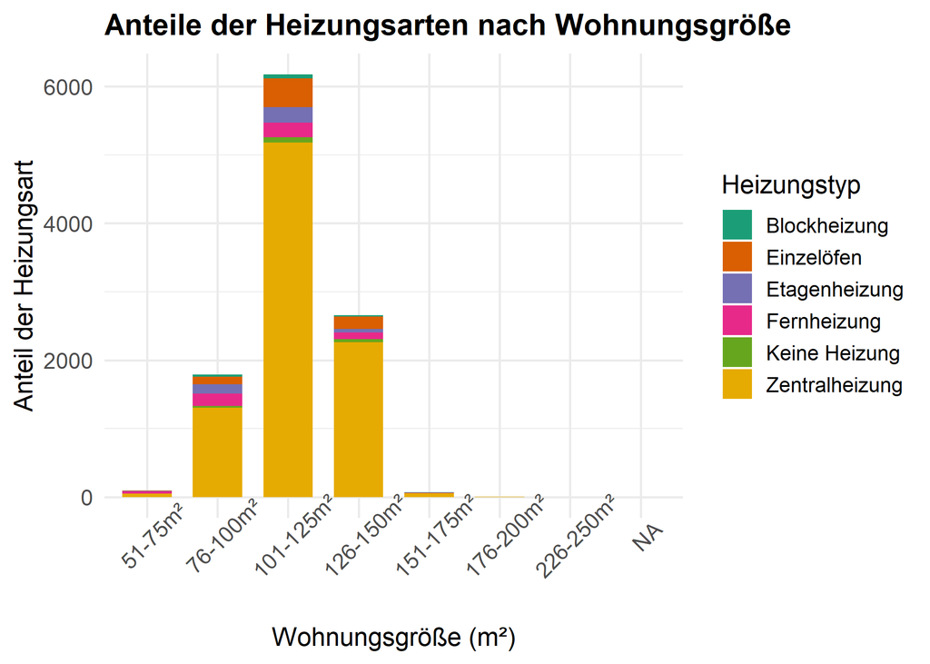

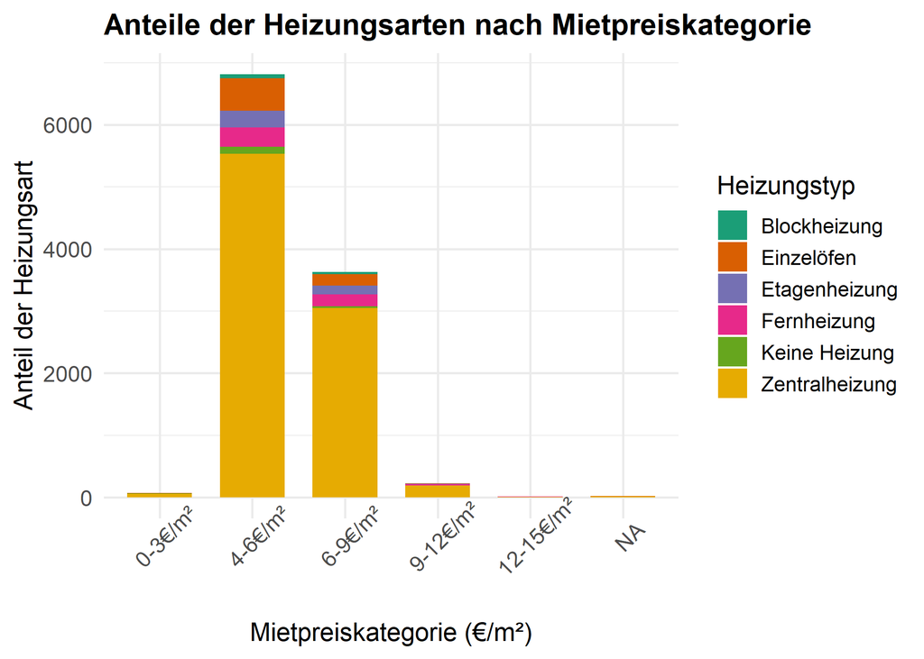

Bei einer Analyse des Zusammenhangs von Heizungsart und Wohnungsgröße fällt auf, dass die Zentralheizung bei allen Wohnungsgrößen dominant vorkommt. Besonders bei Wohnungen im Bereich von 76–125 m² ist ihr Anteil sehr hoch. Blockheizung und Etagenheizung treten deutlich seltener auf und sind eher gleichmäßig über die Wohnungsgrößen verteilt. Einzelöfen sowie Wohnungen ohne Heizung sind bei kleinen und großen Wohnungsgrößen eher selten. Die Fernheizung hat einen merkbaren Anteil, vor allem in den mittleren und größeren Wohnungsgrößen, allerdings nicht so ausgeprägt wie die Zentralheizung. Es zeigt sich, dass größere Wohnungen häufig mit moderneren Heizungsarten wie Zentral- oder Fernheizung ausgestattet sind, da diese effizienter für größere Gebäude sind. Einzelöfen und Etagenheizungen sind typischer in kleineren Wohnungen, die oft in älteren Gebäuden zu finden sind.

Es kann unterschiedliche Gründe für bestimmte Heizungsarten bei unterschiedlichen Wohnungsgrößen geben. Zum einen können kostensparende oder bauliche Faktoren einen Einfluss haben. Zentralheizungen und Fernheizungen sind für größere Gebäude und Wohnungen effizienter, da sie mehrere Wohneinheiten versorgen können. Einzelöfen und Etagenheizungen finden sich oft in kleineren Wohnungen oder Altbauten, da deren Nachrüstung kostspielig ist. Auch historische oder wirtschaftliche Bedingungen können wichtige Faktoren sein. Viele ältere Gebäude verfügen über keine zentrale Heizungsanlage und setzen stattdessen auf Einzelöfen oder Etagenheizungen. Zudem sind günstigere Heizsysteme wie Einzelöfen oft in preisgünstigen Wohnungen eingesetzt.

Bestimmte Heizungsarten lassen sich vermehrt bei Wohnungen mit höheren Mietpreisen finden. Zuerst könnte das auf die Effizienz oder die Modernisierung der Heizungen zurückzuführen sein. Fernheizungen und Zentralheizungen gelten als effizienter, was sich in höheren Mietpreisen widerspiegelt. Außerdem sind Wohnungen mit moderneren Heizungsanlagen häufig Teil von Neubauten oder modernisierten Gebäuden, die generell höherpreisig sind. Auch ist es generell möglich, dass dazu Mieter bereit sind, mehr für eine Wohnung mit moderner Heizung zu zahlen, da diese mit höherem Komfort verbunden sind.

Zuletzt lässt sich erörtern, wie die Bundesregierung trotz neuer Heizungssysteme die Mietpreise regulieren könnte. Zum einen wären Subventionen für Vermieter denkbar, wie die Förderung von modernen Heizungen, ohne die Kosten vollständig auf die Mieter umzulegen. Zudem könnte eine Mietpreisbremse hilfreich sein. Somit gäbe es eine Begrenzung, wie stark die Mieten nach einer Heizungsmodernisierung steigen dürfen. Generell wäre auch die Förderung von alten Wohnungen oder Gebäuden denkbar. So gäbe es Zuschüsse für die Umrüstung von Altbauten, um sie auf moderne Heizsysteme zu bringen, während die Miete weiterhin reguliert bleibt. Auch könnten strengere Energieeffizienzstandards für alle Gebäude sinnvoll sein, da so langfristig Heizungskosten und damit Mietkosten gesenkt werden können.

Wie Sie in der Aufgabe 15 gesehen haben, haben Ulm und Stuttgart, sowie Dresden und Chemnitz ähnliche Verhältnisse bezüglich der Verteilung der Mietkosten über die Stadt hinweg. Aufgrund dessen beschränken Sie sich bei dieser Aufgabe auf die Städte Stuttgart und Dresden. Hier sollen Sie sich die einzelnen Heizungsarten über die Stadtteile hinweg anschauen, wie sich diese verteilen und ob hier Ähnlichkeiten zur Mietpreissstrukur vorliegt. Weiterhin sind vor allem die Heizungsarten Fernwärme, Zentralheizung und Etagenheizung in viele deutschen Wohnungen größtenteils verbaut, weshalb Sie gerade deswegen diese drei Heiztypen genauer beleuchten und untersuchen sollen.

19. Deshalb sollten Sie sich in einem ersten Schritt [diese Geogitter-Daten für die verschiedenen Heinzungsarten vom statistischen Bundesamt herunterladen](https://www.zensus2022.de/static/Zensus_Veroeffentlichung/Zensus2022_Heizungsart.zip). Speichern Sie die zip-Datei im Ordner `Daten` ab. Nutzen Sie erneut den Datensatz shape_file aus der Aufgabe 4 und joinen Sie die Informationen zu den Heizungsarten über die Variablen `x_mp_1km` und `y_mp_1km`.

In ihrem Datensatz können Sie sehen, dass es Einträge mit “-” gibt. Diese sollen sie für alle Heizungstypen durch 0 ersetzen. Achten Sie auch darauf, dass über alle Heizungstypen hinweg die Werte als numeric vorliegen.

Erstellen Sie nun für die Heizungsarten “Fernheizung”, “Etagenheizung” und “Zentralheizung” eine neue Spalte mit dem Anteil des jeweiligen Heizungstyps an allen Heizungen (`Insgesamt_Heizungsart`) je Gemeinde. Schließlich sollen Sie nun für die drei genannten Heizungsarten eine Karte erzeugen, welche den Anteil je Gitterebene im Stadtbezirk darstellt.

Beschreiben und interpretieren Sie ihre Grafiken. Berücksichtigen Sie dabei insbesondere folgende Fragen:

- Wo liegen Besonderheiten oder Muster in beiden Städten?
- Gibt es in Stuttgart und Dresden Stadtteile, bei denen bestimmte Heizungstypen in Einklang mit den Mietpreisen stehen, genauer gesagt, welche Heizungsarten korrelieren mit höheren oder niedrigeren Mietpreisen? Vergleichen Sie dazu die Ergebnisse aus Aufgabe 15.
- Was könnten Gründe sein, dass in bestimmten Stadtteilen vorwiegend eine bestimmte Form der Heizung eingebaut ist?
- Gibt es Unterschiede zwischen Ost- und Westdeutschland?
- Haben die Städte Stuttgart oder Dresden in den letzen Jahren Modernisierungen angestoßen oder Neuerungen umgesetzt und finanziell unterstützt, sodass es dort zu größeren Anpassungen bei der Heizungstechnik kam?

*Hinweis 1:* Sie sollen insgesamt für jede Stadt (Stuttgart und Dresden) drei verschiedene Karten erzeugen.

*Hinweis 2:* Achten Sie auf eine sinnvolle Einteilung und Darstellung in den Karten. Nutzen Sie die Karten aus vorherigen Aufgaben als Hilfestellung.

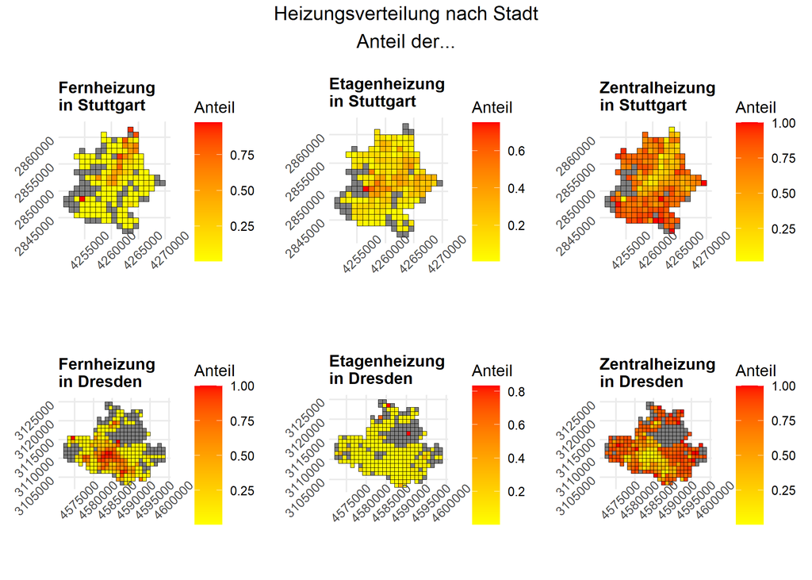

Zur Ideensammlung für die Gestaltung der Karten haben wir die R-Craft-Gallery genutzt. (https://r-graph-gallery.com/79-levelplot-with-ggplot2.html) (https://r-graph-gallery.com/package/sf.html)

Die Grafiken zeigen die Verteilung der Heizungsarten Fernheizung, Etagenheizung und Zentralheizung in den Städten Stuttgart und Dresden. Die Daten sind in einem Raster dargestellt, wobei die Farbintensität den Anteil der jeweiligen Heizungsart in jedem Rasterfeld widerspiegelt. Während hohe Anteile in Rot dargestellt sind, weisen gelbe Felder auf niedrigere Anteile hin.

In Stuttgart zeigt sich ein auffälliges Muster bei der Fernheizung. Hohe Anteile sind vor allem in den nördlichen und zentralen Stadtteilen zu finden. Diese Bereiche dürften von Neubauprojekten dominiert sein, die in den letzten Jahren modernisiert wurden. Die Etagenheizung hingegen ist ungleich verteilt und tritt vor allem in älteren Wohngebieten auf. Die Zentralheizung ist in Stuttgart relativ gleichmäßig verteilt, mit einer stärkeren Konzentration in den südlichen und östlichen Stadtteilen.

Ein interessanter Aspekt ist der Zusammenhang zwischen Heizungsart und Mietpreisen. In Stuttgart und Dresden korrelieren die Heizungsarten Fernheizung und Zentralheizung häufig mit höheren Mietpreisen. Diese Heizsysteme sind effizienter und moderner. In Stadtteilen mit hohen Mietpreisen, wie dem Zentrum von Stuttgart oder der Altstadt von Dresden, sind diese Heizungsarten daher häufiger anzutreffen. Etagenheizungen hingegen finden sich eher in Stadtteilen mit niedrigeren Mietpreisen. Diese Heizsysteme sind weniger effizient und häufig in älteren Gebäuden installiert.

Die Verteilung der Heizungsarten in Stuttgart und Dresden lässt sich auch durch historische und regionale Unterschiede erklären. Dresden als ostdeutsche Stadt ist stark von der DDR-Planwirtschaft geprägt, die auf eine flächendeckende Nutzung der Fernwärme gesetzt haben könnte. Stuttgart hingegen, als westdeutsche Stadt, weist eine größere Vielfalt an Heizsystemen auf. Hier wurde die Fernheizung erst in den letzten Jahrzehnten vermehrt in Neubauprojekten eingeführt.

In den letzten Jahren haben beide Städte umfassende Modernisierungsmaßnahmen durchgeführt. Diese Maßnahmen zielen darauf ab, den CO2-Ausstoß zu reduzieren und die Effizienz zu steigern. Dresden hat ebenfalls Modernisierungsprogramme vorangetrieben. Hier wurde die Infrastruktur der Fernwärme weiter ausgebaut und modernisiert, um den aktuellen Standards der Energieeffizienz zu entsprechen.

Zusammenfassend lässt sich sagen, dass die Verteilung der Heizungsarten in Stuttgart und Dresden sowohl die historische Entwicklung als auch die aktuellen Strategien widerspiegelt. Während Dresden stark von der DDR-Planung geprägt ist, zeigt Stuttgart eine diversifiziertere Struktur, die auf kontinuierliche Modernisierung und den Ausbau effizienter Heizsysteme setzt. Die Korrelation zwischen Heizungsarten und Mietpreisen unterstreicht zudem, dass moderne Heizsysteme in wirtschaftlich stärkeren Stadtteilen bevorzugt werden, während ältere Systeme in weniger attraktiven Wohngebieten zu finden sind.

Abschließend sollen Sie die Zusatzaufgabe noch einmal rekapitulieren und einige Fragen dazu beantworten.

20. Sie sollen sich noch einmal bewusst werden, was Sie in den vorherigen Aufgaben analysiert haben und in welcher Form ihre Ergebnisse anwendbar und verallgemeinbar sind. Beantworten Sie dazu Frage 1 und 2.

Frage 1: Betrachten Sie hierzu noch einmal exemplarisch die Städte Stuttgart und Dresden.

- Sind die Zusammenhänge zwischen Mietpreisen in den Städten und sozioökonomischer Faktoren vor allem auf Unterschiede zwischen den Städten oder auf Unterschiede innerhalb der Stadt zurückzuführen. Bei welchen Faktoren ist dies der Fall, wo nicht?
- Wie kann der Staat im Hinblick auf die unterschiedlichen Heizungsarten in den Städten eingreifen, um Wohnraum preiswerter zu gestalten?

Frage 2: Schauen Sie sich noch einmal die Verteilung der Heizungsarten (Fern-, Etagen- und Zentralheizungen) für Stuttgart und Dresden in Aufgabe 19 an. Betrachten Sie im Vergleich dazu ihre Grafik aus Aufgabe 8, sowie ihre Tabelle in Aufgabe 13?

- Was fällt Ihnen hier auf?
- Gibt es bestimmte Heizungstypen, die nur in alten oder neuen Wohnungen vorkommen?
- Welche Schlüsse würden Sie ziehen, die mit Handlungen der Politik einhergehen?

Frage 1:

Als Teil der ehemaligen DDR unterscheidet sich die Geschichte Dresdens erheblich von der Stuttgarts. Dies zeigt sich zum Beispiel in Bezug auf die Anteile der Heizungsarten, in denen zu sehen ist, dass besonders im Zentrum die Fernwärme stark verbreitet ist. Eine Maßnahme, die aufgrund ihrer wirtschaftlichen Effizienz zu DDR-Zeiten besonders gefördert wurde.

Ebenfalls ist die Arbeitslosenquote Dresdens, wie die vieler ostdeutscher Städte, höher als die der meisten westdeutschen Städte, darunter Stuttgart.

Dagegen ist in Stuttgart, aufgrund seiner langen Geschichte als stabiler Wirtschaftsstandort, die Einkommensstruktur der Bevölkerung auf einem höheren Niveau angesiedelt.

Diese Faktoren sorgen dafür, dass Stuttgart eine sehr attraktive Stadt für Arbeitnehmer und Arbeitgeber ist, sodass auch Investoren in der Immobilienbranche angezogen werden, die dort mit einer höheren Gewinnausschüttung rechnen können.

Dresden, als aufstrebende Großstadt, gewinnt ebenfalls zunehmend an Bedeutung und Attraktivität, was erwarten lässt, dass auch dessen Mietpreise weiterhin steigen werden.

Zu den internen Unterschieden lässt sich sagen, dass Stuttgart ein sehr dominantes Stadtzentrum besitzt, das sich stark in den Mietpreisen widerspiegelt, während dies in Dresden weniger der Fall ist. Dies kann unter anderem mit höheren Investitionen in Modernisierung und Neubau zusammenhängen (siehe Heizungsarten), die wiederum mit der Zahlungsfähigkeit der Bevölkerung in Verbindung stehen.

All dies legt nahe, dass die Zusammenhänge zwischen Mietpreisen in den Städten besonders auf die starken sozioökonomischen Unterschiede zwischen diesen zurückzuführen sind. Da diese Unterschiede mit dem weiteren Wachstum, Wandel und der Vernetzung stetig schwächer werden, wäre zu erwarten, dass sich auch die Mietpreisstrukturen angleichen werden.

Um den Wohnraum preiswerter zu gestalten, kann der Staat in Hinblick auf unterschiedliche Heizungsarten, die Investitionen in die Wohnungen repräsentieren, dahingehend eingreifen, dass moderne Heizungsarten finanziell gefördert werden, beispielsweise durch Subventionen oder Steuervorteile. Wohnungsbau und -modernisierung werden damit vergünstigt und gleichzeitig werden durch diese effizienteren Heizarten die letztendlichen Wohnkosten für die Mieter gesenkt. Bei Einführung derartiger Maßnahmen ist es jedoch wichtig, darauf zu achten, dass die Vergünstigungen tatsächlich an die Mieter weitergegeben werden. Da sich die Mietpreise durch die Knappheit an Wohnraum, vor allem nach der Stärke der Nachfrage, richten und weniger nach der Investitionshöhe, besteht das Risiko, dass lediglich Investoren von derartigen Maßnahmen profitieren, wenn nicht entsprechende Regelungen eingeführt werden. Ein historisches Beispiel für einen solchen Fall sind die Zinssenkungen infolge der Finanzkrise 2009. Diese haben dazu geführt, dass Bodenpreise in die Höhe getrieben wurden, dadurch, dass viele Investoren auf Wertsteigerungen spekulierten. Nach Bebauung wurden diese jedoch Vergünstigungen nicht an die Endverbraucher weitergegeben.

Ein positives Beispiel dagegen ist Wien: Dort ist der Staat Besitzer oder Förderer von etwa der Hälfte der Wohnungen, sodass die Mietpreise für die Bürger bezahlbar bleiben, trotz der Position der Stadt als internationale Metropole, Hauptstadt und berühmtes kulturelles Zentrum.

Frage 2:

Beim Vergleich der Grafiken für Dresden und Stuttgart aus Aufgabe 19 und 13 ist auffällig, dass im Zentrum Stuttgarts, in dem die Nettokaltmieten am höchsten sind, die Fernwärme besonders stark präsent ist.

Betrachtet man zudem noch Aufgabe 8, so ist zu sehen, dass die Bautätigkeit in Stuttgart über die Jahrzehnte abgenommen hat. Neue Wohnungen ab 2010 (entspricht Baujahrgruppen 9 und 10) bilden in Stuttgart und auch in Dresden nur etwa 6,6 % aller Wohnungen, wie der Tabelle in Aufgabe 10 zu entnehmen ist.

Zum zeitlichen Bezug der Heizungsarten lässt sich sagen, dass die Fernwärme bei neueren Wohnungen besonders beliebt ist, da sie allgemein als günstig und nachhaltig angesehen wird. Zentralheizungen sind jedoch stärker etabliert. Insbesondere wurden sie im Wiederaufbau nach dem Zweiten Weltkrieg primär eingesetzt, werden aber bis heute oft eingebaut, besonders außerhalb der Zentren. Einzelöfen dagegen werden heutzutage als eher veraltet angesehen und werden in Neubauten kaum vorzufinden sein. Sie sind eher in älteren Wohnungen in ländlicheren Gebieten zu erwarten.

Der Zusammenhang, dass sich das Stadtzentrum in Dresden nicht durch höhere Mieten hervorhebt, kann daran liegen, dass in Dresden die Fernwärme, anders als in Stuttgart, vom DDR-Staat finanziell gefördert wurde. Dies könnte ein Indiz sein, dass eine staatliche Förderung der Installation moderner Heizarten, wie in Frage 1 vorgeschlagen, einen positiven Effekt auf die Mietpreise haben würde. Die finanziellen Entlastungen durch den Staat wurden hier tatsächlich an die Endverbraucher weitergegeben, indem die Nettomietpreise der Wohnungen mit modernen Heizungen gegenüber anderen Wohnungen nicht erheblich erhöht wurden, sodass die Effekte für die Mieter nicht nur auf eine Senkung der Nebenkosten beschränkt blieben.